# GAMMs LabPhon 18

Jalal Al-Tamimi

Newcastle University

6 June 2018; updated 10 August 2022

# 1 Loading packages

```r
library(ggplot2);library(mgcv);library(itsadug);library(tidyverse);library(gganimate); library(doParallel)
```

# 2 Demo Linear Model vs GAM

In this demo, data obtained from a Jordanian Arabic speaker producing the word /du:d/ “worm” is used. F2 frequencies obtained at 5 ms interval from onset to midpoint of the vowel are used. Let’s plot the F2 frequencies by interval number. The second plot displays a linear regression line superimposed on the plot. As can be seen, the linear regression line is not able to cope with the curviness of the data, and is unable to cope with it. The third plot superimposes a spline obtained from a GAM model.

```r
demoGAMProd <- read.csv("dataProd_duud.csv")
head(demoGAMProd)
```

|  | IntervalsN | F2 |
| --- | --- | --- |
| 1 | 0 | 1721.132 |
| 2 | 1 | 1640.935 |
| 3 | 2 | 1566.011 |
| 4 | 3 | 1506.776 |
| 5 | 4 | 1426.349 |
| 6 | 5 | 1373.035 |

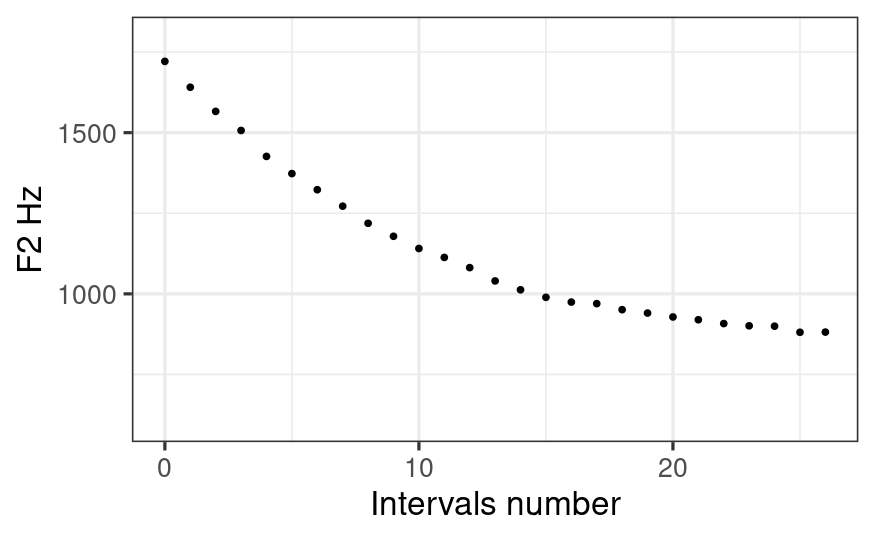

```r
ggplot.demo1 <- ggplot(demoGAMProd,aes(x=IntervalsN,y=F2))+
                geom_point()+theme_bw(base_size = 20)+coord_cartesian(ylim=c(600,1800))+
                labs(y = "F2 Hz", x = "Intervals number")
ggplot.demo1
```

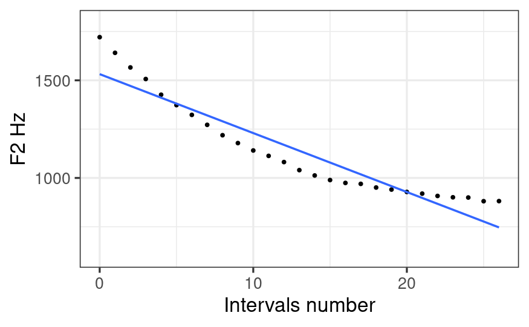

```r
ggplot.demo2 <- ggplot(demoGAMProd,aes(x=IntervalsN,y=F2))+
  geom_point()+theme_bw(base_size = 20)+coord_cartesian(ylim=c(600,1800))+
  labs(y = "F2 Hz", x = "Intervals number")+geom_smooth(method = lm, se=F)

ggplot.demo2
```

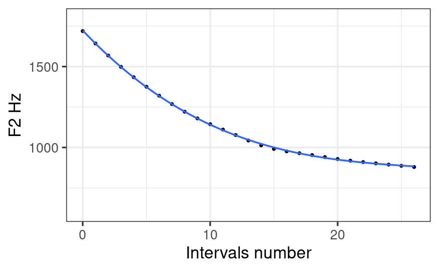

```r
ggplot.demo3 <- ggplot(demoGAMProd,aes(x=IntervalsN,y=predict(bam(F2 ~ s(IntervalsN, bs="cr"), data = demoGAMProd))))+
  geom_point()+theme_bw(base_size = 20)+coord_cartesian(ylim=c(600,1800))+
  labs(y = "F2 Hz", x = "Intervals number")+geom_smooth(method = lm, formula = y ~ splines::bs(x, 3),se=F)

ggplot.demo3
```

# 3 Actual data analyses

This data is obtained from a single speaker producing various consonants in the frame VCV, with V = symmetric /i: a: u:/ (=vowel) and C is one of 17 consonants put into five contexts “plain”, “velar”, “uvular”, “pharyngealised” and “pharyngeal” (=context). The data is from Ultrasound Tongue Imaging. Tongue contours were obtained at the consonant onset, midpoint and offset (=time). A total of 51 words (=word) were obtained and these were repeated 3 times. Tongue splines were extracted with X-Y coordinates (=y outcome). 42 Fan positions (=Fan) were extracted and these are used as a normalisation between contexts. The outcome is y, the predictors are Fan, time, context and vowel, and the random factor is word.

## 3.1 Creating new variables

Before running the actual GAM model on the data, we need to:

1. Create two new variables for context and vowel. These will be “ordered” predictors and sum coded
2. To run an Auto-Regressive Model, we need to find the autocorrelation in the dataframe:
- We rearrange the data by time, ID, and Fan
- We add a new variable “start” that marks the start of Fan

```r
pharDF <- read.csv("resultsFull.c_NoRelNoz.csv")
str(pharDF)
```

```
'data.frame':   18900 obs. of  23 variables:
 $ X.1                        : int  1 2 3 4 5 6 7 8 9 10 ...
 $ ID                         : int  1 2 3 7 8 9 10 11 12 13 ...
 $ Client.Surname             : chr  "Sara" "Sara" "Sara" "Sara" ...
 $ Time.of.sample.in.recording: num  3.84 5.37 2.37 5.3 2.26 ...
 $ Prompt                     : chr  "2aataa.... 2aataa.... 2aataa.... 2aattaa.... 2aattaa.... 2aattaa" "2aataa.... 2aataa.... 2aataa.... 2aattaa.... 2aattaa.... 2aattaa" "2aataa.... 2aataa.... 2aataa.... 2aattaa.... 2aattaa.... 2aattaa" "2aataa.... 2aataa.... 2aataa.... 2aattaa.... 2aattaa.... 2aat…
 $ word                       : chr  "2aataa" "2aataa" "2aataa" "2aataa" ...
 $ context                    : chr  "plain" "plain" "plain" "plain" ...
 $ consonant                  : chr  "t" "t" "t" "t" ...
 $ consType                   : chr  "plosive" "plosive" "plosive" "plosive" ...
 $ vowel                      : chr  "aa" "aa" "aa" "aa" ...
 $ labelNew                   : chr  "CL_Mid" "CL_Mid" "CL_Mid" "CL_Ons" ...
 $ label                      : chr  "CL_Mid" "CL_Mid" "CL_Mid" "CL_Ons" ...
 $ repetition                 : int  2 3 1 3 1 2 3 1 2 2 ...
 $ Fan                        : int  1 1 1 1 1 1 1 1 1 1 ...
 $ x                          : num  18.8 18.9 21.5 19.1 17.7 ...
 $ y                          : num  15.6 15.6 14.1 15.5 16.3 ...
 $ vowel2                     : chr  "aː" "aː" "aː" "aː" ...
 $ labelNew2                  : int  2 2 2 1 1 1 3 3 3 2 ...
 $ context.ord                : chr  "plain" "plain" "plain" "plain" ...
 $ vowel.ord                  : chr  "aa" "aa" "aa" "aa" ...
 $ fan_line                   : int  1 1 1 1 1 1 1 1 1 1 ...
 $ X                          : num  18.8 18.9 21.5 19.1 17.7 ...
 $ Y                          : num  15.6 15.6 14.1 15.5 16.3 ...
```

```r
levels(pharDF$context)
```

```r
pharDF$context <- factor(pharDF$context,
                                levels = c("plain","velar","uvular","pharyngealised","pharyngeal"))
levels(pharDF$vowel)
```

```r
pharDF$vowel <- factor(pharDF$vowel,
                              levels = c("ii","aa","uu"))
levels(pharDF$labelNew)
```

```r
pharDF$labelNew <- factor(pharDF$labelNew,
                                 levels = c("CL_Ons","CL_Mid","CL_Off"))


pharDF$ID <- as.numeric(pharDF$ID)
pharDF$Fan <- as.numeric(pharDF$Fan)
pharDF$labelNew2 <- as.numeric(pharDF$labelNew2)
pharDF$time <- pharDF$labelNew2
pharDF$word <- as.factor(pharDF$word)



pharDF$context.ord <- as.ordered(pharDF$context)
contrasts(pharDF$context.ord) <- "contr.treatment"

pharDF$vowel.ord <- as.ordered(pharDF$vowel)
contrasts(pharDF$vowel.ord) <- "contr.treatment"

## to find autocorrelation in the data. Rearrange dataframe and add a variable "start" to indicate
## when Fan == 1
pharDF <- arrange(pharDF, time, ID, Fan)
pharDF$start <- pharDF$Fan==1
ncores = 10
```

## 3.2 Visualising the data

Before running anything, we start by visualising the data and use an animated figure

```r
pl <- ggplot(pharDF, aes(x=Fan, y=y, col=context, frame=time)) +
  facet_grid(vowel ~ context) +
  geom_line(aes(group=ID))+theme_bw()+
transition_manual(time)
animate(pl, width=800, height=300)
```

```
nframes and fps adjusted to match transition

Rendering [=================>-------------------------------------] at 2.7 fps ~ eta:  1s
Rendering [====================================>------------------] at 2.1 fps ~ eta:  0s
Rendering [=======================================================] at 2.2 fps ~ eta:  0s
```

```
[1] "./gganim_plot0001.png" "./gganim_plot0002.png" "./gganim_plot0003.png"
attr(,"frame_vars")
```

[output not shown]

## 3.3 Running our first GAM model

This is our first GAM model. This will be used to find the level of autocorrelation in the data. Our model has double non-linear predictors (fan and time), two factor predictors (context and vowel) and one random effect (word). Interactions between fan and time are used. In addition, by context*vowel interaction is added to account for the two-way interaction with respect to each of fan and time. The function itsadug::acf_resid is used, and we display the level of autocorrelation for each of the “Fan”, the “time”, the “context”, the “vowel” finally the “word”

```r
mdl.sys.time1 <- system.time(phar.gam.noAR <- bam(y ~ context.ord*vowel.ord +
                        ## 1d smooths
                        s(Fan, bs="cr", k=10) +
                        s(time, bs="cr", k=3) +
                        ## 1d smooths * factors
                        s(Fan, k=10, bs="cr", by=context.ord) +
                        s(Fan, k=10, bs="cr", by=vowel.ord) +
                        s(Fan, k=10, bs="cr", by=interaction(context.ord, vowel.ord)) +
                        s(time, k=3, bs="cr", by=context.ord) +
                        s(time, k=3, bs="cr", by=vowel.ord) +
                        s(time, k=3, bs="cr", by=interaction(context.ord, vowel.ord)) +
                        ## 2d smooths
                        ti(Fan, time, bs="cr", k=c(10,3))+
                        ## 2d smooths * factors
                        ti(Fan, time, bs="cr", k=c(10,3), by=context.ord)+
                        ti(Fan, time, bs="cr", k=c(10,3), by=vowel.ord)+
                        ti(Fan, time, bs="cr", k=c(10,3),by=interaction(context.ord, vowel.ord)) +
                        ## random smooths by word
                        s(Fan, word, bs="fs", k=10, m=1, xt=list(bs = "tp")) +
                        s(time, word, bs="fs", k=3, m=1, xt=list(bs = "tp")),
                        data=pharDF, nthreads = ncores, method="fREML", discrete = TRUE))
mdl.sys.time1
```

```
utilisateur     système      écoulé
     85.518       0.460      23.230
```

### 3.3.1 Summary and Rho

```r
summary(phar.gam.noAR)
```

```
Family: gaussian
Link function: identity

Formula:
y ~ context.ord * vowel.ord + s(Fan, bs = "cr", k = 10) + s(time,
    bs = "cr", k = 3) + s(Fan, k = 10, bs = "cr", by = context.ord) +
    s(Fan, k = 10, bs = "cr", by = vowel.ord) + s(Fan, k = 10,
    bs = "cr", by = interaction(context.ord, vowel.ord)) + s(time,
    k = 3, bs = "cr", by = context.ord) + s(time, k = 3, bs = "cr",
    by = vowel.ord) + s(time, k = 3, bs = "cr", by = interaction(context.ord,
    vowel.ord)) + ti(Fan, time, bs = "cr", k = c(10, 3)) + ti(Fan,
    time, bs = "cr", k = c(10, 3), by = context.ord) + ti(Fan,
    time, bs = "cr", k = c(10, 3), by = vowel.ord) + ti(Fan,
    time, bs = "cr", k = c(10, 3), by = interaction(context.ord,
        vowel.ord)) + s(Fan, word, bs = "fs", k = 10, m = 1,
    xt = list(bs = "tp")) + s(time, word, bs = "fs", k = 3, m = 1,
    xt = list(bs = "tp"))

Parametric coefficients:
                                      Estimate Std. Error t value Pr(>|t|)
(Intercept)                            35.7762     0.3566 100.340  < 2e-16 ***
context.ordvelar                        1.8198     0.5042   3.609 0.000308 ***
context.orduvular                       2.4191     0.7973   3.034 0.002415 **
context.ordpharyngealised               0.8235     0.4784   1.721 0.085191 .
context.ordpharyngeal                   0.5458     0.6176   0.884 0.376842
vowel.ordaa                             0.6929     0.4784   1.449 0.147483
vowel.orduu                             0.9109     0.4784   1.904 0.056902 .
context.ordvelar:vowel.ordaa           -0.6105     0.6950  -0.878 0.379757
context.orduvular:vowel.ordaa          -2.7389     1.1162  -2.454 0.014142 *
context.ordpharyngealised:vowel.ordaa  -1.2107     0.6574  -1.841 0.065572 .
context.ordpharyngeal:vowel.ordaa       0.6388     0.8587   0.744 0.456955
context.ordvelar:vowel.orduu           -2.0721     0.6950  -2.981 0.002875 **
context.orduvular:vowel.orduu          -3.1064     1.1162  -2.783 0.005390 **
context.ordpharyngealised:vowel.orduu  -1.7974     0.6574  -2.734 0.006266 **
context.ordpharyngeal:vowel.orduu      -0.6710     0.8587  -0.781 0.434568
---
Signif. codes:  0 ‘***’ 0.001 ‘**’ 0.01 ‘*’ 0.05 ‘.’ 0.1 ‘ ’ 1

Approximate significance of smooth terms:
                                                                        edf    Ref.df
```

[output cut: 128 more lines]

```
ti(time,Fan):interaction(context.ord, vowel.ord)pharyngealised.aa 134.167  < 2e-16 ***
ti(time,Fan):interaction(context.ord, vowel.ord)pharyngeal.aa       3.090 0.007342 **
ti(time,Fan):interaction(context.ord, vowel.ord)plain.uu            9.768  < 2e-16 ***
ti(time,Fan):interaction(context.ord, vowel.ord)velar.uu            7.195 3.01e-06 ***
ti(time,Fan):interaction(context.ord, vowel.ord)uvular.uu           3.492 6.80e-05 ***
ti(time,Fan):interaction(context.ord, vowel.ord)pharyngealised.uu   6.160 0.013055 *
ti(time,Fan):interaction(context.ord, vowel.ord)pharyngeal.uu      16.508  < 2e-16 ***
s(Fan,word)                                                        30.757  < 2e-16 ***
s(time,word)                                                       11.488  < 2e-16 ***
---
Signif. codes:  0 ‘***’ 0.001 ‘**’ 0.01 ‘*’ 0.05 ‘.’ 0.1 ‘ ’ 1

Rank: 1282/1303
R-sq.(adj) =  0.986   Deviance explained = 98.6%
fREML =  35486  Scale est. = 2.2096    n = 18900
```

```r
rho_est <- start_value_rho(phar.gam.noAR)
rho_est
```

```
[1] 0.9416749
```

### 3.3.2 ACF first GAM

#### 3.3.2.1 ACF by Fan

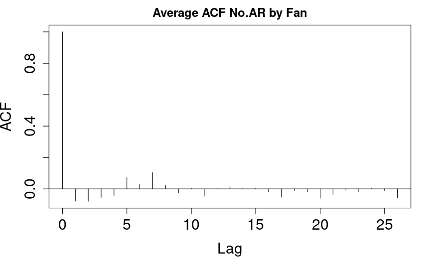

```r
acf_resid(phar.gam.noAR,split_pred=list(pharDF$Fan),main = "Average ACF No.AR by Fan",cex.lab=1.5,cex.axis=1.5)
```

#### 3.3.2.2 ACF by Time

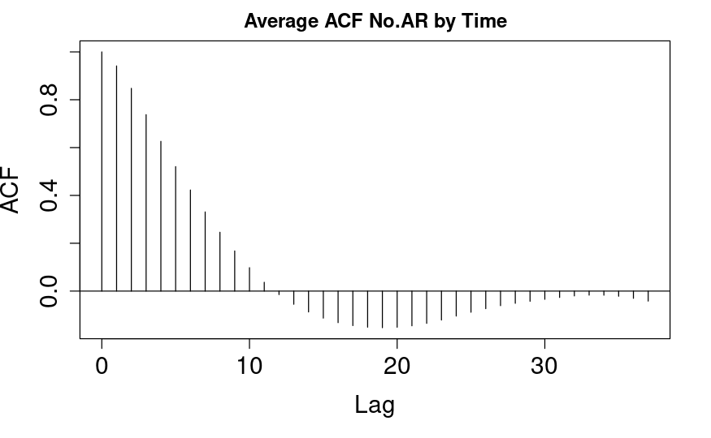

```r
acf_resid(phar.gam.noAR,split_pred=list(pharDF$time),main = "Average ACF No.AR by Time",cex.lab=1.5,cex.axis=1.5)
```

#### 3.3.2.3 ACF by Context

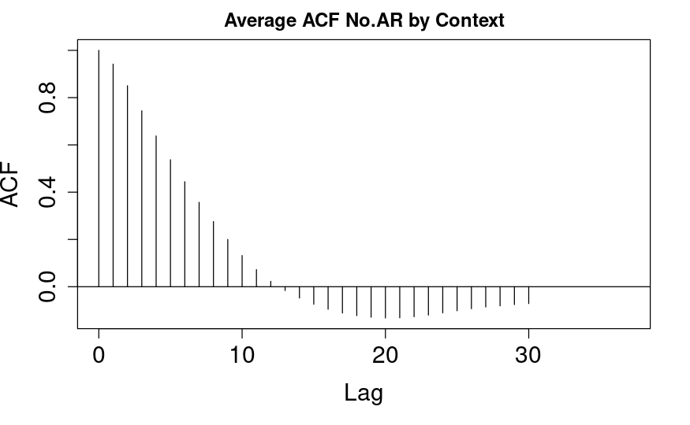

```r
acf_resid(phar.gam.noAR,split_pred=list(pharDF$context.ord),main = "Average ACF No.AR by Context",cex.lab=1.5,cex.axis=1.5)
```

#### 3.3.2.4 ACF by Vowel

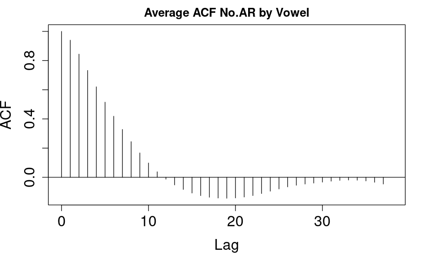

```r
acf_resid(phar.gam.noAR,split_pred=list(pharDF$vowel.ord),main = "Average ACF No.AR by Vowel",cex.lab=1.5,cex.axis=1.5)
```

#### 3.3.2.5 ACF by Word

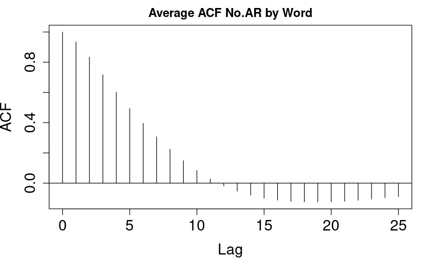

```r
acf_resid(phar.gam.noAR,split_pred=list(pharDF$word),main = "Average ACF No.AR by Word",cex.lab=1.5,cex.axis=1.5)
```

## 3.4 Running our second Autoregressive GAM

Our second GAM model is identical to the first, but takes into account the autocorrelation. By including AR.start and rho, we are using information obtained from original model to account for the autocorrelation

```r
mdl.sys.time2 <- system.time(phar.gam.AR <- bam(y ~ context.ord*vowel.ord +
                       ## 1d smooths
                       s(Fan, bs="cr", k=10) +
                       s(time, bs="cr", k=3) +
                       ## 1d smooths * factors
                       s(Fan, k=10, bs="cr", by=context.ord) +
                       s(Fan, k=10, bs="cr", by=vowel.ord) +
                       s(Fan, k=10, bs="cr", by=interaction(context.ord, vowel.ord)) +
                       s(time, k=3, bs="cr", by=context.ord) +
                       s(time, k=3, bs="cr", by=vowel.ord) +
                       s(time, k=3, bs="cr", by=interaction(context.ord, vowel.ord)) +
                       ## 2d smooths
                       ti(Fan, time, bs="cr", k=c(10,3))+
                       ## 2d smooths * factors
                       ti(Fan, time, bs="cr", k=c(10,3), by=context.ord)+
                       ti(Fan, time, bs="cr", k=c(10,3), by=vowel.ord)+
                       ti(Fan, time, bs="cr", k=c(10,3),  by=interaction(context.ord, vowel.ord))+
                       ## random smooths by word
                       s(Fan, word, bs="fs", k=10, m=1, xt=list(bs = "tp")) +
                       s(time, word, bs="fs", k=3, m=1, xt=list(bs = "tp")),
                       data=pharDF,
                       AR.start=pharDF$start, rho=rho_est, nthreads = ncores, method="fREML", discrete = TRUE))
mdl.sys.time2
```

```
utilisateur     système      écoulé
     89.537       0.438      21.479
```

### 3.4.1 Summary

```r
summary(phar.gam.AR)
```

```
Family: gaussian
Link function: identity

Formula:
y ~ context.ord * vowel.ord + s(Fan, bs = "cr", k = 10) + s(time,
    bs = "cr", k = 3) + s(Fan, k = 10, bs = "cr", by = context.ord) +
    s(Fan, k = 10, bs = "cr", by = vowel.ord) + s(Fan, k = 10,
    bs = "cr", by = interaction(context.ord, vowel.ord)) + s(time,
    k = 3, bs = "cr", by = context.ord) + s(time, k = 3, bs = "cr",
    by = vowel.ord) + s(time, k = 3, bs = "cr", by = interaction(context.ord,
    vowel.ord)) + ti(Fan, time, bs = "cr", k = c(10, 3)) + ti(Fan,
    time, bs = "cr", k = c(10, 3), by = context.ord) + ti(Fan,
    time, bs = "cr", k = c(10, 3), by = vowel.ord) + ti(Fan,
    time, bs = "cr", k = c(10, 3), by = interaction(context.ord,
        vowel.ord)) + s(Fan, word, bs = "fs", k = 10, m = 1,
    xt = list(bs = "tp")) + s(time, word, bs = "fs", k = 3, m = 1,
    xt = list(bs = "tp"))

Parametric coefficients:
                                      Estimate Std. Error t value Pr(>|t|)
(Intercept)                            35.7836     0.3498 102.295  < 2e-16 ***
context.ordvelar                        1.8356     0.4947   3.711 0.000207 ***
context.orduvular                       2.4247     0.7819   3.101 0.001933 **
context.ordpharyngealised               0.8374     0.4693   1.785 0.074347 .
context.ordpharyngeal                   0.5581     0.6059   0.921 0.356992
vowel.ordaa                             0.7040     0.4693   1.500 0.133574
vowel.orduu                             0.9126     0.4693   1.945 0.051834 .
context.ordvelar:vowel.ordaa           -0.6253     0.6818  -0.917 0.359087
context.orduvular:vowel.ordaa          -2.7150     1.0942  -2.481 0.013103 *
context.ordpharyngealised:vowel.ordaa  -1.2354     0.6450  -1.915 0.055454 .
context.ordpharyngeal:vowel.ordaa       0.6256     0.8423   0.743 0.457665
context.ordvelar:vowel.orduu           -2.0672     0.6818  -3.032 0.002434 **
context.orduvular:vowel.orduu          -3.1006     1.0949  -2.832 0.004632 **
context.ordpharyngealised:vowel.orduu  -1.8018     0.6448  -2.794 0.005209 **
context.ordpharyngeal:vowel.orduu      -0.6707     0.8424  -0.796 0.425971
---
Signif. codes:  0 ‘***’ 0.001 ‘**’ 0.01 ‘*’ 0.05 ‘.’ 0.1 ‘ ’ 1

Approximate significance of smooth terms:
                                                                        edf    Ref.df
```

[output cut: 128 more lines]

```
ti(time,Fan):interaction(context.ord, vowel.ord)pharyngealised.aa   0.000  0.99973
ti(time,Fan):interaction(context.ord, vowel.ord)pharyngeal.aa       1.413  0.16403
ti(time,Fan):interaction(context.ord, vowel.ord)plain.uu            2.310  0.00357 **
ti(time,Fan):interaction(context.ord, vowel.ord)velar.uu            1.727  0.12905
ti(time,Fan):interaction(context.ord, vowel.ord)uvular.uu           1.500  0.11389
ti(time,Fan):interaction(context.ord, vowel.ord)pharyngealised.uu   0.080  0.97179
ti(time,Fan):interaction(context.ord, vowel.ord)pharyngeal.uu       6.158  < 2e-16 ***
s(Fan,word)                                                        12.279  < 2e-16 ***
s(time,word)                                                        0.190  < 2e-16 ***
---
Signif. codes:  0 ‘***’ 0.001 ‘**’ 0.01 ‘*’ 0.05 ‘.’ 0.1 ‘ ’ 1

Rank: 1284/1303
R-sq.(adj) =  0.984   Deviance explained = 98.5%
fREML =  12752  Scale est. = 1.6981    n = 18900
```

### 3.4.2 ACF second GAM

The following five plots show (in the same order as above) the autocorrelation in the residuals. As can be seen, for all five plots, the levels of autocorrelations in the residuals are reduced massively. We have now more confidence in our estimates, and can continue work

#### 3.4.2.1 ACF by Fan

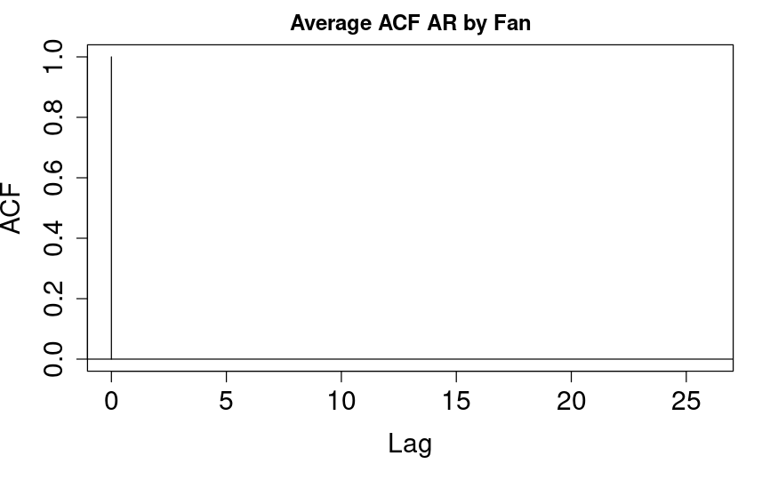

```r
acf_resid(phar.gam.AR,split_pred=list(pharDF$Fan),main = "Average ACF AR by Fan",cex.lab=1.5,cex.axis=1.5)
```

#### 3.4.2.2 ACF by Time

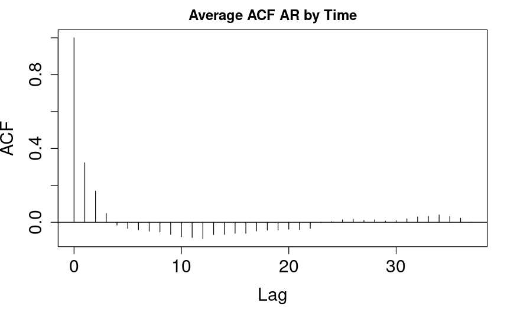

```r
acf_resid(phar.gam.AR,split_pred=list(pharDF$time),main = "Average ACF AR by Time",cex.lab=1.5,cex.axis=1.5)
```

#### 3.4.2.3 ACF by Context

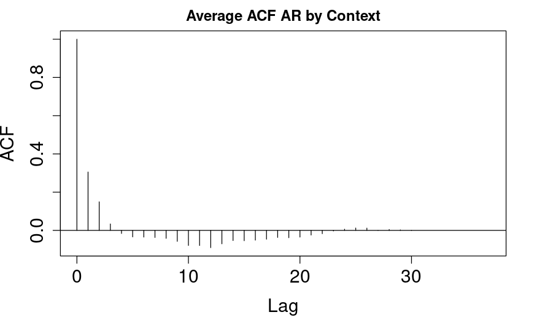

```r
acf_resid(phar.gam.AR,split_pred=list(pharDF$context.ord),main = "Average ACF AR by Context",cex.lab=1.5,cex.axis=1.5)
```

#### 3.4.2.4 ACF by Vowel

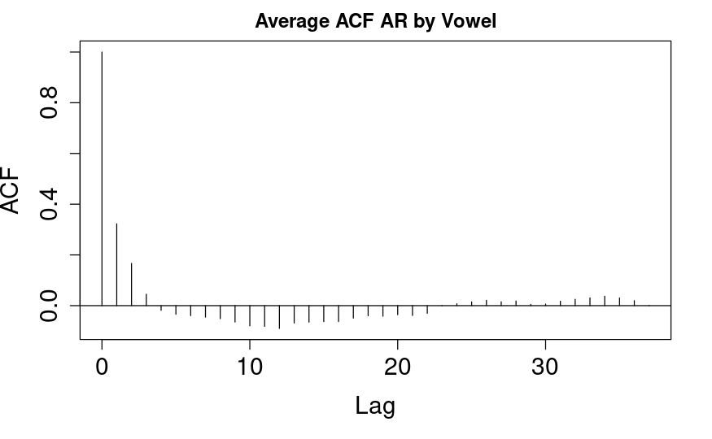

```r
acf_resid(phar.gam.AR,split_pred=list(pharDF$vowel.ord),main = "Average ACF AR by Vowel",cex.lab=1.5,cex.axis=1.5)
```

#### 3.4.2.5 ACF by Word

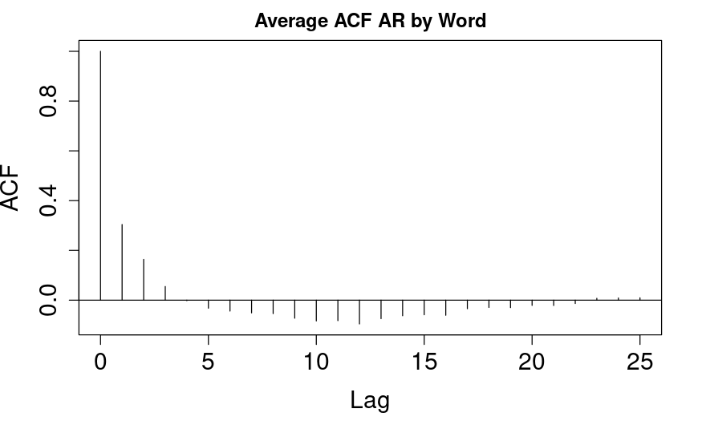

```r
acf_resid(phar.gam.AR,split_pred=list(pharDF$word),main = "Average ACF AR by Word",cex.lab=1.5,cex.axis=1.5)
```

### 3.4.3 Gam Check

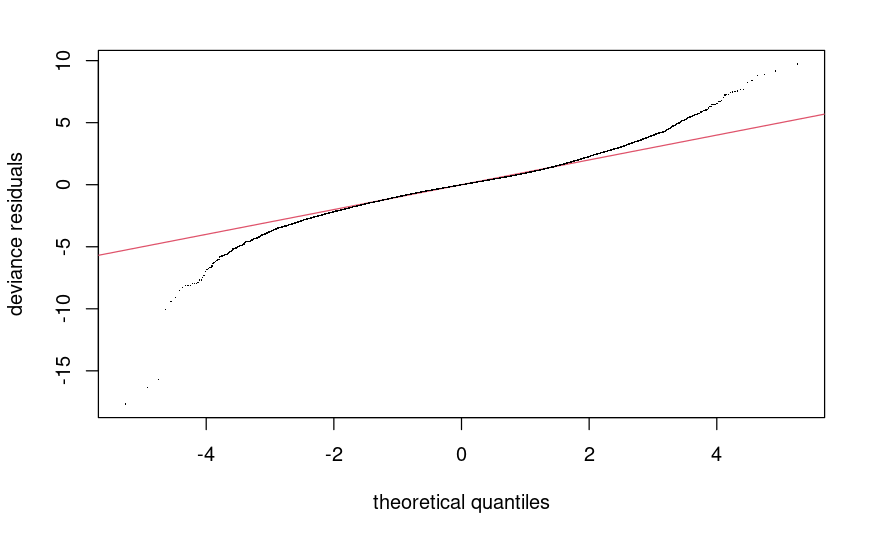

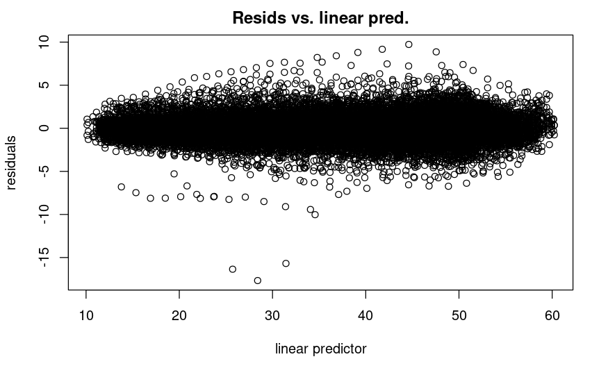

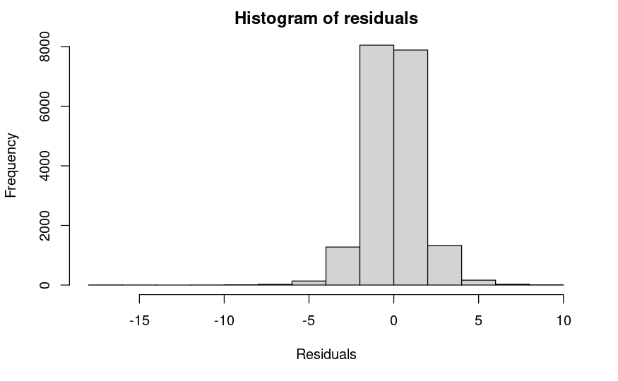

[output not shown]

[output cut: 288 more lines]

```
ti(time,Fan):interaction(context.ord, vowel.ord)pharyngeal.ii        0.98   0.150
ti(time,Fan):interaction(context.ord, vowel.ord)plain.aa             0.98   0.155
ti(time,Fan):interaction(context.ord, vowel.ord)velar.aa             0.98   0.145
ti(time,Fan):interaction(context.ord, vowel.ord)uvular.aa            0.98   0.165
ti(time,Fan):interaction(context.ord, vowel.ord)pharyngealised.aa    0.98   0.130
ti(time,Fan):interaction(context.ord, vowel.ord)pharyngeal.aa        0.98   0.125
ti(time,Fan):interaction(context.ord, vowel.ord)plain.uu             0.98   0.180
ti(time,Fan):interaction(context.ord, vowel.ord)velar.uu             0.98   0.165
ti(time,Fan):interaction(context.ord, vowel.ord)uvular.uu            0.98   0.125
ti(time,Fan):interaction(context.ord, vowel.ord)pharyngealised.uu    0.98   0.095 .
ti(time,Fan):interaction(context.ord, vowel.ord)pharyngeal.uu        0.98   0.090 .
s(Fan,word)                                                          1.03   0.980
s(time,word)                                                         1.02   0.865
---
Signif. codes:  0 ‘***’ 0.001 ‘**’ 0.01 ‘*’ 0.05 ‘.’ 0.1 ‘ ’ 1
```

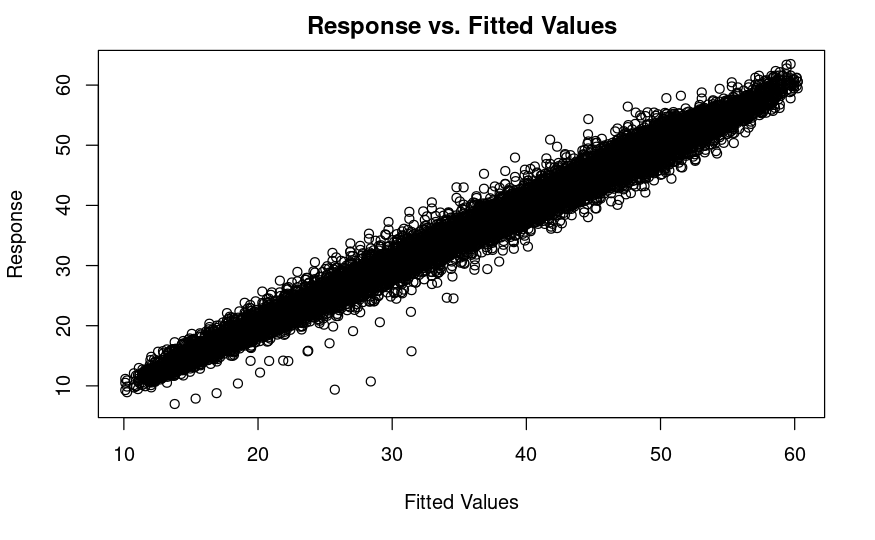

```r
gam.check(phar.gam.AR)
```

## 3.5 Significance testing second Autoregressive GAM

To test for significance of context, we run a model with a ML as method and evaluate significance through a maximum likelihood estimate.

### 3.5.1 Models

We ran three models

1. A full model with all predictors (phar.gam.AR.ML)
2. A reduced model without any terms associated with the predictor “context” (phar.gam.AR.ML.Min.Context)
3. An intercept only model (=Null) without any terms associated with the predictor “vowel” (phar.gam.AR.ML.Min.ContextAndVowel)

```r
mdl.sys.time3 <- system.time(phar.gam.AR.ML <- bam(y ~ context.ord*vowel.ord +
                           # 1d smooths
                           s(Fan, bs="cr",k=10) +
                           s(time, bs="cr", k=3) +
                           # 1d smooth * factor
                           s(Fan, k=10, bs="cr", by=context.ord) +
                           s(Fan, k=10, bs="cr", by=vowel.ord) +
                           s(Fan, k=10, bs="cr", by=interaction(context.ord, vowel.ord)) +
                           s(time, k=3, bs="cr", by=context.ord) +
                           s(time, k=3, bs="cr", by=vowel.ord) +
                           s(time, k=3, bs="cr", by=interaction(context.ord, vowel.ord)) +
                           # 2d smooth
                           ti(Fan, time, bs="cr", k=c(10,3))+
                           ti(Fan, time, bs="cr", k=c(10,3),by=context.ord)+
                           ti(Fan, time, bs="cr", k=c(10,3),by=vowel.ord)+
                           ti(Fan, time, bs="cr", k=c(10,3),by=interaction(context.ord, vowel.ord))+
                           # random smooths by word
                           s(Fan, word, bs="fs", k=10, m=1, xt=list(bs = "tp")) +
                           s(time, word, bs="fs", k=3, m=1, xt=list(bs = "tp")),
                           data=pharDF,
                           method="ML",
                           AR.start=pharDF$start, rho=rho_est, nthreads = ncores, discrete = TRUE))

mdl.sys.time3
```

```
utilisateur     système      écoulé
  21433.768     179.089   12276.728
```

```r
mdl.sys.time4 <- system.time(phar.gam.AR.ML.Min.Context <- bam(y ~ vowel.ord +
                                      # 1d smooths
                                      s(Fan, bs="cr",k=10) +
                                      s(time, bs="cr", k=3) +
                                      # 1d smooth * factor
                                      ##s(Fan, k=10, bs="cr", by=context.ord) +
                                      s(Fan, k=10, bs="cr", by=vowel.ord) +
                                      ##s(Fan, k=10, bs="cr", by=context.ord:vowel.ord) +
                                      ##s(time, k=3, bs="cr", by=context.ord) +
                                      s(time, k=3, bs="cr", by=vowel.ord) +
                                      ##s(time, k=3, bs="cr", by=context.ord:vowel.ord) +
                                      # 2d smooth
                                      ti(Fan, time, bs="cr", k=c(10,3))+
                                      ##ti(Fan, time, bs="cr", k=c(10,3),by=context.ord)+
                                      ###ti(Fan, time, bs="cr", k=c(10,3),by=vowel.ord)+
                                      ##ti(Fan, time, bs="cr", k=c(10,3),by=context.ord:vowel.ord)+
                                      # random smooths by word
                                      s(Fan, word, bs="fs", k=10, m=1, xt=list(bs = "tp")) +
                                      s(time, word, bs="fs", k=3, m=1, xt=list(bs = "tp")),
                                      data=pharDF,
                                      method="ML",
                                      AR.start=pharDF$start, rho=rho_est, nthreads = ncores, discrete = TRUE))
mdl.sys.time4
```

```
utilisateur     système      écoulé
    474.920       7.668     251.698
```

```r
mdl.sys.time5 <- system.time(phar.gam.AR.ML.Min.ContextAndVowel <- bam(y ~ 1 +
                                    # 1d smooths
                                    s(Fan, bs="cr",k=10) +
                                    s(time, bs="cr", k=3) +
                                    # 1d smooth * factor
                                    ##s(Fan, k=10, bs="cr", by=context.ord) +
                                    ###s(Fan, k=10, bs="cr", by=vowel.ord) +
                                    ##s(Fan, k=10, bs="cr", by=context.ord:vowel.ord) +
                                    ##s(time, k=3, bs="cr", by=context.ord) +
                                    ###s(time, k=3, bs="cr", by=vowel.ord) +
                                    ##s(time, k=3, bs="cr", by=context.ord:vowel.ord) +
                                    # 2d smooth
                                    ##ti(Fan, time, bs="cr", k=c(10,3),by=context.ord)+
                                    ###ti(Fan, time, bs="cr", k=c(10,3),by=vowel.ord)+
                                    ##ti(Fan, time, bs="cr", k=c(10,3),by=context.ord:vowel.ord)+
                                    # random smooths by word
                                    s(Fan, word, bs="fs", k=10, m=1, xt=list(bs = "tp")) +
                                    s(time, word, bs="fs", k=3, m=1, xt=list(bs = "tp")),
                                    data=pharDF,
                                    method="ML",
                                    AR.start=pharDF$start, rho=rho_est, nthreads = ncores, discrete = TRUE))
mdl.sys.time5
```

```
utilisateur     système      écoulé
    832.054      13.665     387.945
```

### 3.5.2 Model comparison

Then we compare results of these models as shown below.

#### 3.5.2.1 Effect of Context vs null

```r
compareML(phar.gam.AR.ML, phar.gam.AR.ML.Min.Context)
```

```
phar.gam.AR.ML: y ~ context.ord * vowel.ord + s(Fan, bs = "cr", k = 10) + s(time,
    bs = "cr", k = 3) + s(Fan, k = 10, bs = "cr", by = context.ord) +
    s(Fan, k = 10, bs = "cr", by = vowel.ord) + s(Fan, k = 10,
    bs = "cr", by = interaction(context.ord, vowel.ord)) + s(time,
    k = 3, bs = "cr", by = context.ord) + s(time, k = 3, bs = "cr",
    by = vowel.ord) + s(time, k = 3, bs = "cr", by = interaction(context.ord,
    vowel.ord)) + ti(Fan, time, bs = "cr", k = c(10, 3)) + ti(Fan,
    time, bs = "cr", k = c(10, 3), by = context.ord) + ti(Fan,
    time, bs = "cr", k = c(10, 3), by = vowel.ord) + ti(Fan,
    time, bs = "cr", k = c(10, 3), by = interaction(context.ord,
        vowel.ord)) + s(Fan, word, bs = "fs", k = 10, m = 1,
    xt = list(bs = "tp")) + s(time, word, bs = "fs", k = 3, m = 1,
    xt = list(bs = "tp"))

phar.gam.AR.ML.Min.Context: y ~ vowel.ord + s(Fan, bs = "cr", k = 10) + s(time, bs = "cr",
    k = 3) + s(Fan, k = 10, bs = "cr", by = vowel.ord) + s(time,
    k = 3, bs = "cr", by = vowel.ord) + ti(Fan, time, bs = "cr",
    k = c(10, 3)) + s(Fan, word, bs = "fs", k = 10, m = 1, xt = list(bs = "tp")) +
    s(time, word, bs = "fs", k = 3, m = 1, xt = list(bs = "tp"))

Chi-square test of ML scores
-----
```

| Model | Score | Edf | Difference | Df | p.value | Sig. |
| --- | --- | --- | --- | --- | --- | --- |
| phar.gam.AR.ML.Min.Context | 14216.80 | 22 |  |  |  |  |
| phar.gam.AR.ML | 12828.79 | 173 | 1388.001 | 151.000 | < 2e-16 | *** |

```
AIC difference: -2736.64, model phar.gam.AR.ML has lower AIC.
```

#### 3.5.2.2 Effect of Vowel vs Null

```r
compareML(phar.gam.AR.ML,phar.gam.AR.ML.Min.ContextAndVowel)
```

```
phar.gam.AR.ML: y ~ context.ord * vowel.ord + s(Fan, bs = "cr", k = 10) + s(time,
    bs = "cr", k = 3) + s(Fan, k = 10, bs = "cr", by = context.ord) +
    s(Fan, k = 10, bs = "cr", by = vowel.ord) + s(Fan, k = 10,
    bs = "cr", by = interaction(context.ord, vowel.ord)) + s(time,
    k = 3, bs = "cr", by = context.ord) + s(time, k = 3, bs = "cr",
    by = vowel.ord) + s(time, k = 3, bs = "cr", by = interaction(context.ord,
    vowel.ord)) + ti(Fan, time, bs = "cr", k = c(10, 3)) + ti(Fan,
    time, bs = "cr", k = c(10, 3), by = context.ord) + ti(Fan,
    time, bs = "cr", k = c(10, 3), by = vowel.ord) + ti(Fan,
    time, bs = "cr", k = c(10, 3), by = interaction(context.ord,
        vowel.ord)) + s(Fan, word, bs = "fs", k = 10, m = 1,
    xt = list(bs = "tp")) + s(time, word, bs = "fs", k = 3, m = 1,
    xt = list(bs = "tp"))

phar.gam.AR.ML.Min.ContextAndVowel: y ~ 1 + s(Fan, bs = "cr", k = 10) + s(time, bs = "cr", k = 3) +
    s(Fan, word, bs = "fs", k = 10, m = 1, xt = list(bs = "tp")) +
    s(time, word, bs = "fs", k = 3, m = 1, xt = list(bs = "tp"))

Chi-square test of ML scores
-----
```

| Model | Score | Edf | Difference | Df | p.value | Sig. |
| --- | --- | --- | --- | --- | --- | --- |
| phar.gam.AR.ML.Min.ContextAndVowel | 14419.99 | 9 |  |  |  |  |
| phar.gam.AR.ML | 12828.79 | 173 | 1591.192 | 164.000 | < 2e-16 | *** |

```
AIC difference: -3053.28, model phar.gam.AR.ML has lower AIC.
```

#### 3.5.2.3 Effect of Context vs Vowel

```r
compareML(phar.gam.AR.ML.Min.Context,phar.gam.AR.ML.Min.ContextAndVowel)
```

```
phar.gam.AR.ML.Min.Context: y ~ vowel.ord + s(Fan, bs = "cr", k = 10) + s(time, bs = "cr",
    k = 3) + s(Fan, k = 10, bs = "cr", by = vowel.ord) + s(time,
    k = 3, bs = "cr", by = vowel.ord) + ti(Fan, time, bs = "cr",
    k = c(10, 3)) + s(Fan, word, bs = "fs", k = 10, m = 1, xt = list(bs = "tp")) +
    s(time, word, bs = "fs", k = 3, m = 1, xt = list(bs = "tp"))

phar.gam.AR.ML.Min.ContextAndVowel: y ~ 1 + s(Fan, bs = "cr", k = 10) + s(time, bs = "cr", k = 3) +
    s(Fan, word, bs = "fs", k = 10, m = 1, xt = list(bs = "tp")) +
    s(time, word, bs = "fs", k = 3, m = 1, xt = list(bs = "tp"))

Chi-square test of ML scores
-----
```

| Model | Score | Edf | Difference | Df | p.value | Sig. |
| --- | --- | --- | --- | --- | --- | --- |
| phar.gam.AR.ML.Min.ContextAndVowel | 14419.99 | 9 |  |  |  |  |
| phar.gam.AR.ML.Min.Context | 14216.80 | 22 | 203.191 | 13.000 | < 2e-16 | *** |

```
AIC difference: -316.64, model phar.gam.AR.ML.Min.Context has lower AIC.
```

From the results above, both “context” and “vowel” are improving the model fit. “Context” is improving the model fit more than “vowel” (see 3rd comparison)

## 3.6 Visualising smooths from second Autoregressive GAM

We use the function itsadug::plot_smooth to plot the five smooths for context “plain”, “velar”, “uvular”, “pharyngealised” and “pharyngeal”, in each of the vowel contexts /i: a: u:/ at the onset, midpoint and offset.

The results show that at the midpoint and offset, the three contexts, uvular, pharyngealised and pharyngeal are different from each other: uvular has a higher tongue position (y coordinate); intermediate in pharyngealised and lower and fronted in pharyngeal. At the onset, the same pattern is seen though to a lower degree in /a:/.

### 3.6.1 Vowel /i:/

#### 3.6.1.1 Onset

```r
plot_smooth(phar.gam.AR, view = "Fan",cond = list(context.ord="plain",vowel.ord="ii",time=1),col="darkmagenta",ylim = c(10,65),ylab="",xlab="",
            main="GAM smooths in /i:/ at Onset",hide.label=T,cex.axis=1.3,rm.ranef=T)
```

```
Summary:
    * context.ord : factor; set to the value(s): plain.
    * vowel.ord : factor; set to the value(s): ii.
    * Fan : numeric predictor; with 30 values ranging from 1.000000 to 42.000000.
    * time : numeric predictor; set to the value(s): 1.
    * word : factor; set to the value(s): 2aa3aa. (Might be canceled as random effect, check below.)
    * NOTE : The following random effects columns are canceled: s(Fan,word),s(time,word)
```

```r
plot_smooth(phar.gam.AR, view = "Fan",cond = list(context.ord="velar",vowel.ord="ii",time=1),col="gray70",add=TRUE,ylim = c(10,65),hide.label=T,cex.axis=1.3,rm.ranef=T)
```

```
Summary:
    * context.ord : factor; set to the value(s): velar.
    * vowel.ord : factor; set to the value(s): ii.
    * Fan : numeric predictor; with 30 values ranging from 1.000000 to 42.000000.
    * time : numeric predictor; set to the value(s): 1.
    * word : factor; set to the value(s): 2aa3aa. (Might be canceled as random effect, check below.)
    * NOTE : The following random effects columns are canceled: s(Fan,word),s(time,word)
```

```r
plot_smooth(phar.gam.AR, view = "Fan",cond = list(context.ord="uvular",vowel.ord="ii",time=1),col="green",add=TRUE,ylim = c(10,65),hide.label=T,cex.axis=1.3,rm.ranef=T)
```

```
Summary:
    * context.ord : factor; set to the value(s): uvular.
    * vowel.ord : factor; set to the value(s): ii.
    * Fan : numeric predictor; with 30 values ranging from 1.000000 to 42.000000.
    * time : numeric predictor; set to the value(s): 1.
    * word : factor; set to the value(s): 2aa3aa. (Might be canceled as random effect, check below.)
    * NOTE : The following random effects columns are canceled: s(Fan,word),s(time,word)
```

```r
plot_smooth(phar.gam.AR, view = "Fan",cond = list(context.ord="pharyngealised",vowel.ord="ii",time=1),col="red",add=TRUE,ylim = c(10,65),hide.label=T,cex.axis=1.3,rm.ranef=T)
```

```
Summary:
    * context.ord : factor; set to the value(s): pharyngealised.
    * vowel.ord : factor; set to the value(s): ii.
    * Fan : numeric predictor; with 30 values ranging from 1.000000 to 42.000000.
    * time : numeric predictor; set to the value(s): 1.
    * word : factor; set to the value(s): 2aa3aa. (Might be canceled as random effect, check below.)
    * NOTE : The following random effects columns are canceled: s(Fan,word),s(time,word)
```

```r
plot_smooth(phar.gam.AR, view = "Fan",cond = list(context.ord="pharyngeal",vowel.ord="ii",time=1),col="blue",add=TRUE,ylim = c(10,65),hide.label=T,cex.axis=1.3,rm.ranef=T)
```

```
Summary:
    * context.ord : factor; set to the value(s): pharyngeal.
    * vowel.ord : factor; set to the value(s): ii.
    * Fan : numeric predictor; with 30 values ranging from 1.000000 to 42.000000.
    * time : numeric predictor; set to the value(s): 1.
    * word : factor; set to the value(s): 2aa3aa. (Might be canceled as random effect, check below.)
    * NOTE : The following random effects columns are canceled: s(Fan,word),s(time,word)
```

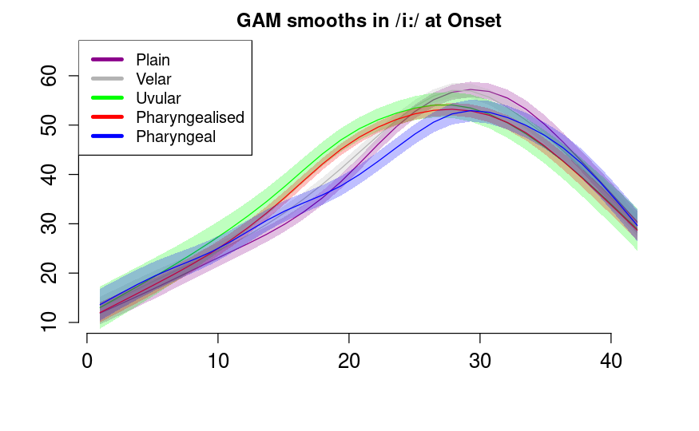

```r
legend("topleft", legend=c("Plain", "Velar", "Uvular","Pharyngealised","Pharyngeal"),
       col=c("darkmagenta","gray70","green","red","blue"), lwd=4)
```

#### 3.6.1.2 Midpoint

```r
plot_smooth(phar.gam.AR, view = "Fan",cond = list(context.ord="plain",vowel.ord="ii",time=2),col="darkmagenta",ylim = c(10,65),ylab="",xlab="",
            main="GAM smooths in /i:/ at Mid",hide.label=T,cex.axis=1.3,rm.ranef=T)
```

```
Summary:
    * context.ord : factor; set to the value(s): plain.
    * vowel.ord : factor; set to the value(s): ii.
    * Fan : numeric predictor; with 30 values ranging from 1.000000 to 42.000000.
    * time : numeric predictor; set to the value(s): 2.
    * word : factor; set to the value(s): 2aa3aa. (Might be canceled as random effect, check below.)
    * NOTE : The following random effects columns are canceled: s(Fan,word),s(time,word)
```

```r
plot_smooth(phar.gam.AR, view = "Fan",cond = list(context.ord="velar",vowel.ord="ii",time=2),col="gray70",add=TRUE,ylim = c(10,65),hide.label=T,cex.axis=1.3,rm.ranef=T)
```

```
Summary:
    * context.ord : factor; set to the value(s): velar.
    * vowel.ord : factor; set to the value(s): ii.
    * Fan : numeric predictor; with 30 values ranging from 1.000000 to 42.000000.
    * time : numeric predictor; set to the value(s): 2.
    * word : factor; set to the value(s): 2aa3aa. (Might be canceled as random effect, check below.)
    * NOTE : The following random effects columns are canceled: s(Fan,word),s(time,word)
```

```r
plot_smooth(phar.gam.AR, view = "Fan",cond = list(context.ord="uvular",vowel.ord="ii",time=2),col="green",add=TRUE,ylim = c(10,65),hide.label=T,cex.axis=1.3,rm.ranef=T)
```

```
Summary:
    * context.ord : factor; set to the value(s): uvular.
    * vowel.ord : factor; set to the value(s): ii.
    * Fan : numeric predictor; with 30 values ranging from 1.000000 to 42.000000.
    * time : numeric predictor; set to the value(s): 2.
    * word : factor; set to the value(s): 2aa3aa. (Might be canceled as random effect, check below.)
    * NOTE : The following random effects columns are canceled: s(Fan,word),s(time,word)
```

```r
plot_smooth(phar.gam.AR, view = "Fan",cond = list(context.ord="pharyngealised",vowel.ord="ii",time=2),col="red",add=TRUE,ylim = c(10,65),hide.label=T,cex.axis=1.3,rm.ranef=T)
```

```
Summary:
    * context.ord : factor; set to the value(s): pharyngealised.
    * vowel.ord : factor; set to the value(s): ii.
    * Fan : numeric predictor; with 30 values ranging from 1.000000 to 42.000000.
    * time : numeric predictor; set to the value(s): 2.
    * word : factor; set to the value(s): 2aa3aa. (Might be canceled as random effect, check below.)
    * NOTE : The following random effects columns are canceled: s(Fan,word),s(time,word)
```

```r
plot_smooth(phar.gam.AR, view = "Fan",cond = list(context.ord="pharyngeal",vowel.ord="ii",time=2),col="blue",add=TRUE,ylim = c(10,65),hide.label=T,cex.axis=1.3,rm.ranef=T)
```

```
Summary:
    * context.ord : factor; set to the value(s): pharyngeal.
    * vowel.ord : factor; set to the value(s): ii.
    * Fan : numeric predictor; with 30 values ranging from 1.000000 to 42.000000.
    * time : numeric predictor; set to the value(s): 2.
    * word : factor; set to the value(s): 2aa3aa. (Might be canceled as random effect, check below.)
    * NOTE : The following random effects columns are canceled: s(Fan,word),s(time,word)
```

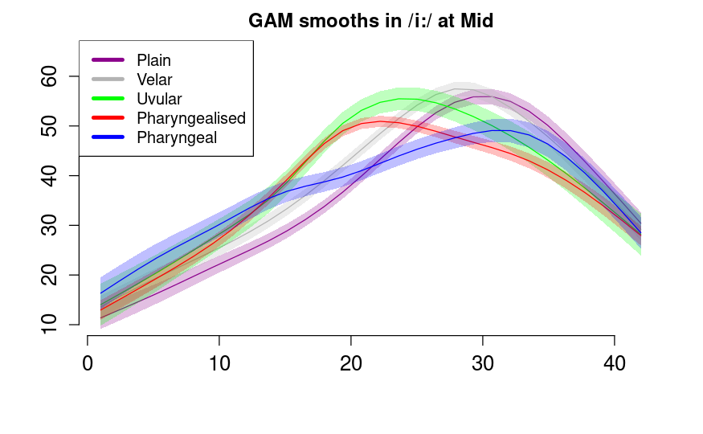

```r
legend("topleft", legend=c("Plain", "Velar", "Uvular","Pharyngealised","Pharyngeal"),
       col=c("darkmagenta","gray70","green","red","blue"), lwd=4)
```

#### 3.6.1.3 Offset

```r
plot_smooth(phar.gam.AR, view = "Fan",cond = list(context.ord="plain",vowel.ord="ii",time=3),col="darkmagenta",ylim = c(10,65),ylab="",xlab="",
            main="GAM smooths in /i:/ at Offset",hide.label=T,cex.axis=1.3,rm.ranef=T)
```

```
Summary:
    * context.ord : factor; set to the value(s): plain.
    * vowel.ord : factor; set to the value(s): ii.
    * Fan : numeric predictor; with 30 values ranging from 1.000000 to 42.000000.
    * time : numeric predictor; set to the value(s): 3.
    * word : factor; set to the value(s): 2aa3aa. (Might be canceled as random effect, check below.)
    * NOTE : The following random effects columns are canceled: s(Fan,word),s(time,word)
```

```r
plot_smooth(phar.gam.AR, view = "Fan",cond = list(context.ord="velar",vowel.ord="ii",time=3),col="gray70",add=TRUE,ylim = c(10,65),hide.label=T,cex.axis=1.3,rm.ranef=T)
```

```
Summary:
    * context.ord : factor; set to the value(s): velar.
    * vowel.ord : factor; set to the value(s): ii.
    * Fan : numeric predictor; with 30 values ranging from 1.000000 to 42.000000.
    * time : numeric predictor; set to the value(s): 3.
    * word : factor; set to the value(s): 2aa3aa. (Might be canceled as random effect, check below.)
    * NOTE : The following random effects columns are canceled: s(Fan,word),s(time,word)
```

```r
plot_smooth(phar.gam.AR, view = "Fan",cond = list(context.ord="uvular",vowel.ord="ii",time=3),col="green",add=TRUE,ylim = c(10,65),hide.label=T,cex.axis=1.3,rm.ranef=T)
```

```
Summary:
    * context.ord : factor; set to the value(s): uvular.
    * vowel.ord : factor; set to the value(s): ii.
    * Fan : numeric predictor; with 30 values ranging from 1.000000 to 42.000000.
    * time : numeric predictor; set to the value(s): 3.
    * word : factor; set to the value(s): 2aa3aa. (Might be canceled as random effect, check below.)
    * NOTE : The following random effects columns are canceled: s(Fan,word),s(time,word)
```

```r
plot_smooth(phar.gam.AR, view = "Fan",cond = list(context.ord="pharyngealised",vowel.ord="ii",time=3),col="red",add=TRUE,ylim = c(10,65),hide.label=T,cex.axis=1.3,rm.ranef=T)
```

```
Summary:
    * context.ord : factor; set to the value(s): pharyngealised.
    * vowel.ord : factor; set to the value(s): ii.
    * Fan : numeric predictor; with 30 values ranging from 1.000000 to 42.000000.
    * time : numeric predictor; set to the value(s): 3.
    * word : factor; set to the value(s): 2aa3aa. (Might be canceled as random effect, check below.)
    * NOTE : The following random effects columns are canceled: s(Fan,word),s(time,word)
```

```r
plot_smooth(phar.gam.AR, view = "Fan",cond = list(context.ord="pharyngeal",vowel.ord="ii",time=3),col="blue",add=TRUE,ylim = c(10,65),hide.label=T,cex.axis=1.3,rm.ranef=T)
```

```
Summary:
    * context.ord : factor; set to the value(s): pharyngeal.
    * vowel.ord : factor; set to the value(s): ii.
    * Fan : numeric predictor; with 30 values ranging from 1.000000 to 42.000000.
    * time : numeric predictor; set to the value(s): 3.
    * word : factor; set to the value(s): 2aa3aa. (Might be canceled as random effect, check below.)
    * NOTE : The following random effects columns are canceled: s(Fan,word),s(time,word)
```

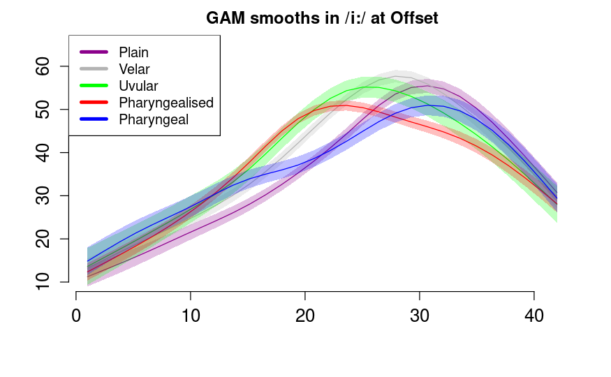

```r
legend("topleft", legend=c("Plain", "Velar", "Uvular","Pharyngealised","Pharyngeal"),
       col=c("darkmagenta","gray70","green","red","blue"), lwd=4)
```

### 3.6.2 Vowel /a:/

#### 3.6.2.1 Onset

```r
plot_smooth(phar.gam.AR, view = "Fan",cond = list(context.ord="plain",vowel.ord="aa",time=1),col="darkmagenta",ylim = c(10,65),ylab="",xlab="",
            main="GAM smooths in /a:/ at Onset",hide.label=T,cex.axis=1.3,rm.ranef=T)
```

```
Summary:
    * context.ord : factor; set to the value(s): plain.
    * vowel.ord : factor; set to the value(s): aa.
    * Fan : numeric predictor; with 30 values ranging from 1.000000 to 42.000000.
    * time : numeric predictor; set to the value(s): 1.
    * word : factor; set to the value(s): 2aa3aa. (Might be canceled as random effect, check below.)
    * NOTE : The following random effects columns are canceled: s(Fan,word),s(time,word)
```

```r
plot_smooth(phar.gam.AR, view = "Fan",cond = list(context.ord="velar",vowel.ord="aa",time=1),col="gray70",add=TRUE,ylim = c(10,65),hide.label=T,cex.axis=1.3,rm.ranef=T)
```

```
Summary:
    * context.ord : factor; set to the value(s): velar.
    * vowel.ord : factor; set to the value(s): aa.
    * Fan : numeric predictor; with 30 values ranging from 1.000000 to 42.000000.
    * time : numeric predictor; set to the value(s): 1.
    * word : factor; set to the value(s): 2aa3aa. (Might be canceled as random effect, check below.)
    * NOTE : The following random effects columns are canceled: s(Fan,word),s(time,word)
```

```r
plot_smooth(phar.gam.AR, view = "Fan",cond = list(context.ord="uvular",vowel.ord="aa",time=1),col="green",add=TRUE,ylim = c(10,65),hide.label=T,cex.axis=1.3,rm.ranef=T)
```

```
Summary:
    * context.ord : factor; set to the value(s): uvular.
    * vowel.ord : factor; set to the value(s): aa.
    * Fan : numeric predictor; with 30 values ranging from 1.000000 to 42.000000.
    * time : numeric predictor; set to the value(s): 1.
    * word : factor; set to the value(s): 2aa3aa. (Might be canceled as random effect, check below.)
    * NOTE : The following random effects columns are canceled: s(Fan,word),s(time,word)
```

```r
plot_smooth(phar.gam.AR, view = "Fan",cond = list(context.ord="pharyngealised",vowel.ord="aa",time=1),col="red",add=TRUE,ylim = c(10,65),hide.label=T,cex.axis=1.3,rm.ranef=T)
```

```
Summary:
    * context.ord : factor; set to the value(s): pharyngealised.
    * vowel.ord : factor; set to the value(s): aa.
    * Fan : numeric predictor; with 30 values ranging from 1.000000 to 42.000000.
    * time : numeric predictor; set to the value(s): 1.
    * word : factor; set to the value(s): 2aa3aa. (Might be canceled as random effect, check below.)
    * NOTE : The following random effects columns are canceled: s(Fan,word),s(time,word)
```

```r
plot_smooth(phar.gam.AR, view = "Fan",cond = list(context.ord="pharyngeal",vowel.ord="aa",time=1),col="blue",add=TRUE,ylim = c(10,65),hide.label=T,cex.axis=1.3,rm.ranef=T)
```

```
Summary:
    * context.ord : factor; set to the value(s): pharyngeal.
    * vowel.ord : factor; set to the value(s): aa.
    * Fan : numeric predictor; with 30 values ranging from 1.000000 to 42.000000.
    * time : numeric predictor; set to the value(s): 1.
    * word : factor; set to the value(s): 2aa3aa. (Might be canceled as random effect, check below.)
    * NOTE : The following random effects columns are canceled: s(Fan,word),s(time,word)
```

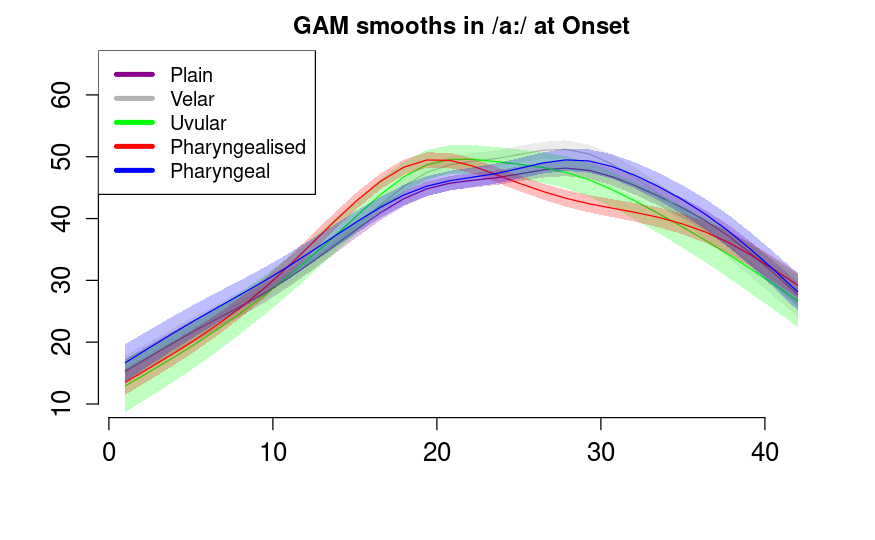

```r
legend("topleft", legend=c("Plain", "Velar", "Uvular","Pharyngealised","Pharyngeal"),
       col=c("darkmagenta","gray70","green","red","blue"), lwd=4)
```

#### 3.6.2.2 Midpoint

```r
plot_smooth(phar.gam.AR, view = "Fan",cond = list(context.ord="plain",vowel.ord="aa",time=2),col="darkmagenta",ylim = c(10,65),ylab="",xlab="",
            main="GAM smooths in /a:/ at Mid",hide.label=T,cex.axis=1.3,rm.ranef=T)
```

```
Summary:
    * context.ord : factor; set to the value(s): plain.
    * vowel.ord : factor; set to the value(s): aa.
    * Fan : numeric predictor; with 30 values ranging from 1.000000 to 42.000000.
    * time : numeric predictor; set to the value(s): 2.
    * word : factor; set to the value(s): 2aa3aa. (Might be canceled as random effect, check below.)
    * NOTE : The following random effects columns are canceled: s(Fan,word),s(time,word)
```

```r
plot_smooth(phar.gam.AR, view = "Fan",cond = list(context.ord="velar",vowel.ord="aa",time=2),col="gray70",add=TRUE,ylim = c(10,65),hide.label=T,cex.axis=1.3,rm.ranef=T)
```

```
Summary:
    * context.ord : factor; set to the value(s): velar.
    * vowel.ord : factor; set to the value(s): aa.
    * Fan : numeric predictor; with 30 values ranging from 1.000000 to 42.000000.
    * time : numeric predictor; set to the value(s): 2.
    * word : factor; set to the value(s): 2aa3aa. (Might be canceled as random effect, check below.)
    * NOTE : The following random effects columns are canceled: s(Fan,word),s(time,word)
```

```r
plot_smooth(phar.gam.AR, view = "Fan",cond = list(context.ord="uvular",vowel.ord="aa",time=2),col="green",add=TRUE,ylim = c(10,65),hide.label=T,cex.axis=1.3,rm.ranef=T)
```

```
Summary:
    * context.ord : factor; set to the value(s): uvular.
    * vowel.ord : factor; set to the value(s): aa.
    * Fan : numeric predictor; with 30 values ranging from 1.000000 to 42.000000.
    * time : numeric predictor; set to the value(s): 2.
    * word : factor; set to the value(s): 2aa3aa. (Might be canceled as random effect, check below.)
    * NOTE : The following random effects columns are canceled: s(Fan,word),s(time,word)
```

```r
plot_smooth(phar.gam.AR, view = "Fan",cond = list(context.ord="pharyngealised",vowel.ord="aa",time=2),col="red",add=TRUE,ylim = c(10,65),hide.label=T,cex.axis=1.3,rm.ranef=T)
```

```
Summary:
    * context.ord : factor; set to the value(s): pharyngealised.
    * vowel.ord : factor; set to the value(s): aa.
    * Fan : numeric predictor; with 30 values ranging from 1.000000 to 42.000000.
    * time : numeric predictor; set to the value(s): 2.
    * word : factor; set to the value(s): 2aa3aa. (Might be canceled as random effect, check below.)
    * NOTE : The following random effects columns are canceled: s(Fan,word),s(time,word)
```

```r
plot_smooth(phar.gam.AR, view = "Fan",cond = list(context.ord="pharyngeal",vowel.ord="aa",time=2),col="blue",add=TRUE,ylim = c(10,65),hide.label=T,cex.axis=1.3,rm.ranef=T)
```

```
Summary:
    * context.ord : factor; set to the value(s): pharyngeal.
    * vowel.ord : factor; set to the value(s): aa.
    * Fan : numeric predictor; with 30 values ranging from 1.000000 to 42.000000.
    * time : numeric predictor; set to the value(s): 2.
    * word : factor; set to the value(s): 2aa3aa. (Might be canceled as random effect, check below.)
    * NOTE : The following random effects columns are canceled: s(Fan,word),s(time,word)
```

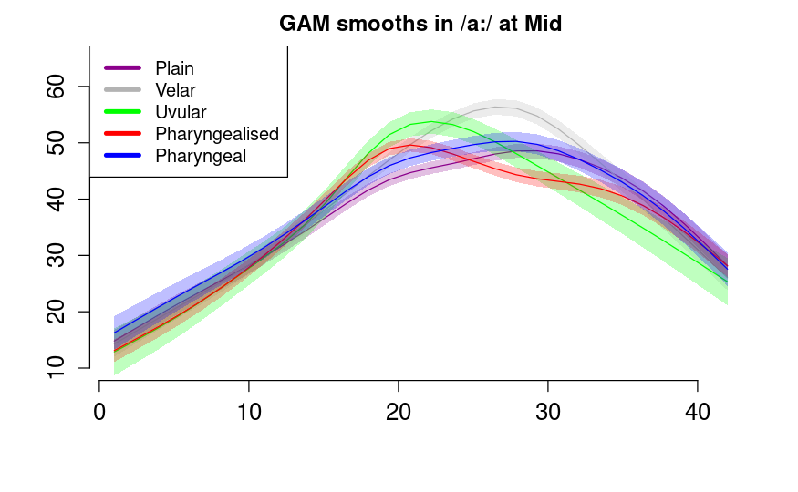

```r
legend("topleft", legend=c("Plain", "Velar", "Uvular","Pharyngealised","Pharyngeal"),
       col=c("darkmagenta","gray70","green","red","blue"), lwd=4)
```

#### 3.6.2.3 Offset

```r
plot_smooth(phar.gam.AR, view = "Fan",cond = list(context.ord="plain",vowel.ord="aa",time=3),col="darkmagenta",ylim = c(10,65),ylab="",xlab="",
            main="GAM smooths in /a:/ at Offset",hide.label=T,cex.axis=1.3,rm.ranef=T)
```

```
Summary:
    * context.ord : factor; set to the value(s): plain.
    * vowel.ord : factor; set to the value(s): aa.
    * Fan : numeric predictor; with 30 values ranging from 1.000000 to 42.000000.
    * time : numeric predictor; set to the value(s): 3.
    * word : factor; set to the value(s): 2aa3aa. (Might be canceled as random effect, check below.)
    * NOTE : The following random effects columns are canceled: s(Fan,word),s(time,word)
```

```r
plot_smooth(phar.gam.AR, view = "Fan",cond = list(context.ord="velar",vowel.ord="aa",time=3),col="gray70",add=TRUE,ylim = c(10,65),hide.label=T,cex.axis=1.3,rm.ranef=T)
```

```
Summary:
    * context.ord : factor; set to the value(s): velar.
    * vowel.ord : factor; set to the value(s): aa.
    * Fan : numeric predictor; with 30 values ranging from 1.000000 to 42.000000.
    * time : numeric predictor; set to the value(s): 3.
    * word : factor; set to the value(s): 2aa3aa. (Might be canceled as random effect, check below.)
    * NOTE : The following random effects columns are canceled: s(Fan,word),s(time,word)
```

```r
plot_smooth(phar.gam.AR, view = "Fan",cond = list(context.ord="uvular",vowel.ord="aa",time=3),col="green",add=TRUE,ylim = c(10,65),hide.label=T,cex.axis=1.3,rm.ranef=T)
```

```
Summary:
    * context.ord : factor; set to the value(s): uvular.
    * vowel.ord : factor; set to the value(s): aa.
    * Fan : numeric predictor; with 30 values ranging from 1.000000 to 42.000000.
    * time : numeric predictor; set to the value(s): 3.
    * word : factor; set to the value(s): 2aa3aa. (Might be canceled as random effect, check below.)
    * NOTE : The following random effects columns are canceled: s(Fan,word),s(time,word)
```

```r
plot_smooth(phar.gam.AR, view = "Fan",cond = list(context.ord="pharyngealised",vowel.ord="aa",time=3),col="red",add=TRUE,ylim = c(10,65),hide.label=T,cex.axis=1.3,rm.ranef=T)
```

```
Summary:
    * context.ord : factor; set to the value(s): pharyngealised.
    * vowel.ord : factor; set to the value(s): aa.
    * Fan : numeric predictor; with 30 values ranging from 1.000000 to 42.000000.
    * time : numeric predictor; set to the value(s): 3.
    * word : factor; set to the value(s): 2aa3aa. (Might be canceled as random effect, check below.)
    * NOTE : The following random effects columns are canceled: s(Fan,word),s(time,word)
```

```r
plot_smooth(phar.gam.AR, view = "Fan",cond = list(context.ord="pharyngeal",vowel.ord="aa",time=3),col="blue",add=TRUE,ylim = c(10,65),hide.label=T,cex.axis=1.3,rm.ranef=T)
```

```
Summary:
    * context.ord : factor; set to the value(s): pharyngeal.
    * vowel.ord : factor; set to the value(s): aa.
    * Fan : numeric predictor; with 30 values ranging from 1.000000 to 42.000000.
    * time : numeric predictor; set to the value(s): 3.
    * word : factor; set to the value(s): 2aa3aa. (Might be canceled as random effect, check below.)
    * NOTE : The following random effects columns are canceled: s(Fan,word),s(time,word)
```

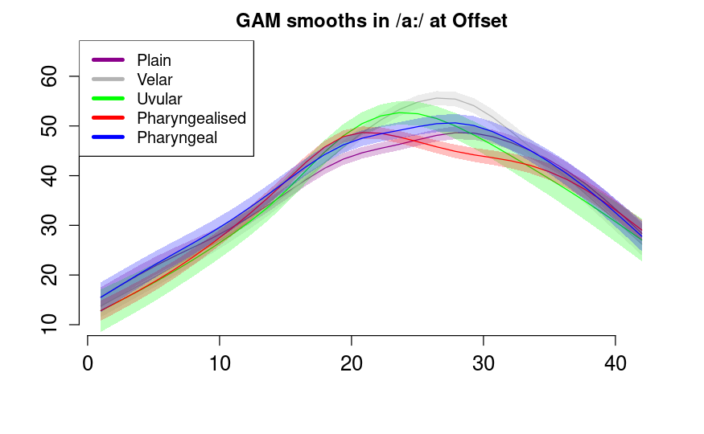

```r
legend("topleft", legend=c("Plain", "Velar", "Uvular","Pharyngealised","Pharyngeal"),
       col=c("darkmagenta","gray70","green","red","blue"), lwd=4)
```

### 3.6.3 Vowel /u:/

#### 3.6.3.1 Onset

```r
plot_smooth(phar.gam.AR, view = "Fan",cond = list(context.ord="plain",vowel.ord="uu",time=1),col="darkmagenta",ylim = c(10,65),ylab="",xlab="",
            main="GAM smooths in /u:/ at Onset",hide.label=T,cex.axis=1.3,rm.ranef=T)
```

```
Summary:
    * context.ord : factor; set to the value(s): plain.
    * vowel.ord : factor; set to the value(s): uu.
    * Fan : numeric predictor; with 30 values ranging from 1.000000 to 42.000000.
    * time : numeric predictor; set to the value(s): 1.
    * word : factor; set to the value(s): 2aa3aa. (Might be canceled as random effect, check below.)
    * NOTE : The following random effects columns are canceled: s(Fan,word),s(time,word)
```

```r
plot_smooth(phar.gam.AR, view = "Fan",cond = list(context.ord="velar",vowel.ord="uu",time=1),col="gray70",add=TRUE,ylim = c(10,65),hide.label=T,cex.axis=1.3,rm.ranef=T)
```

```
Summary:
    * context.ord : factor; set to the value(s): velar.
    * vowel.ord : factor; set to the value(s): uu.
    * Fan : numeric predictor; with 30 values ranging from 1.000000 to 42.000000.
    * time : numeric predictor; set to the value(s): 1.
    * word : factor; set to the value(s): 2aa3aa. (Might be canceled as random effect, check below.)
    * NOTE : The following random effects columns are canceled: s(Fan,word),s(time,word)
```

```r
plot_smooth(phar.gam.AR, view = "Fan",cond = list(context.ord="uvular",vowel.ord="uu",time=1),col="green",add=TRUE,ylim = c(10,65),hide.label=T,cex.axis=1.3,rm.ranef=T)
```

```
Summary:
    * context.ord : factor; set to the value(s): uvular.
    * vowel.ord : factor; set to the value(s): uu.
    * Fan : numeric predictor; with 30 values ranging from 1.000000 to 42.000000.
    * time : numeric predictor; set to the value(s): 1.
    * word : factor; set to the value(s): 2aa3aa. (Might be canceled as random effect, check below.)
    * NOTE : The following random effects columns are canceled: s(Fan,word),s(time,word)
```

```r
plot_smooth(phar.gam.AR, view = "Fan",cond = list(context.ord="pharyngealised",vowel.ord="uu",time=1),col="red",add=TRUE,ylim = c(10,65),hide.label=T,cex.axis=1.3,rm.ranef=T)
```

```
Summary:
    * context.ord : factor; set to the value(s): pharyngealised.
    * vowel.ord : factor; set to the value(s): uu.
    * Fan : numeric predictor; with 30 values ranging from 1.000000 to 42.000000.
    * time : numeric predictor; set to the value(s): 1.
    * word : factor; set to the value(s): 2aa3aa. (Might be canceled as random effect, check below.)
    * NOTE : The following random effects columns are canceled: s(Fan,word),s(time,word)
```

```r
plot_smooth(phar.gam.AR, view = "Fan",cond = list(context.ord="pharyngeal",vowel.ord="uu",time=1),col="blue",add=TRUE,ylim = c(10,65),hide.label=T,cex.axis=1.3,rm.ranef=T)
```

```
Summary:
    * context.ord : factor; set to the value(s): pharyngeal.
    * vowel.ord : factor; set to the value(s): uu.
    * Fan : numeric predictor; with 30 values ranging from 1.000000 to 42.000000.
    * time : numeric predictor; set to the value(s): 1.
    * word : factor; set to the value(s): 2aa3aa. (Might be canceled as random effect, check below.)
    * NOTE : The following random effects columns are canceled: s(Fan,word),s(time,word)
```

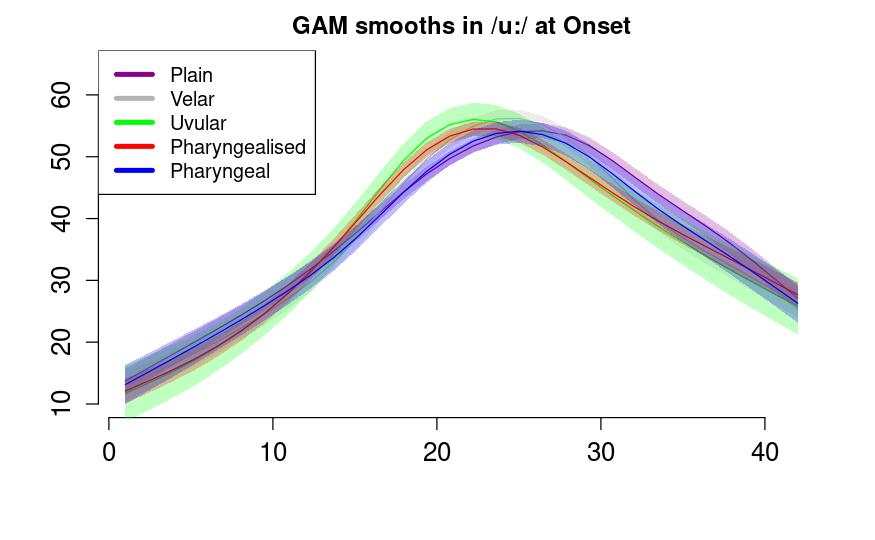

```r
legend("topleft", legend=c("Plain", "Velar", "Uvular","Pharyngealised","Pharyngeal"),
       col=c("darkmagenta","gray70","green","red","blue"), lwd=4)
```

#### 3.6.3.2 Midpoint

```r
plot_smooth(phar.gam.AR, view = "Fan",cond = list(context.ord="plain",vowel.ord="uu",time=2),col="darkmagenta",ylim = c(10,65),ylab="",xlab="",
            main="GAM smooths in /u:/ at Mid",hide.label=T,cex.axis=1.3,rm.ranef=T)
```

```
Summary:
    * context.ord : factor; set to the value(s): plain.
    * vowel.ord : factor; set to the value(s): uu.
    * Fan : numeric predictor; with 30 values ranging from 1.000000 to 42.000000.
    * time : numeric predictor; set to the value(s): 2.
    * word : factor; set to the value(s): 2aa3aa. (Might be canceled as random effect, check below.)
    * NOTE : The following random effects columns are canceled: s(Fan,word),s(time,word)
```

```r
plot_smooth(phar.gam.AR, view = "Fan",cond = list(context.ord="velar",vowel.ord="uu",time=2),col="gray70",add=TRUE,ylim = c(10,65),hide.label=T,cex.axis=1.3,rm.ranef=T)
```

```
Summary:
    * context.ord : factor; set to the value(s): velar.
    * vowel.ord : factor; set to the value(s): uu.
    * Fan : numeric predictor; with 30 values ranging from 1.000000 to 42.000000.
    * time : numeric predictor; set to the value(s): 2.
    * word : factor; set to the value(s): 2aa3aa. (Might be canceled as random effect, check below.)
    * NOTE : The following random effects columns are canceled: s(Fan,word),s(time,word)
```

```r
plot_smooth(phar.gam.AR, view = "Fan",cond = list(context.ord="uvular",vowel.ord="uu",time=2),col="green",add=TRUE,ylim = c(10,65),hide.label=T,cex.axis=1.3,rm.ranef=T)
```

```
Summary:
    * context.ord : factor; set to the value(s): uvular.
    * vowel.ord : factor; set to the value(s): uu.
    * Fan : numeric predictor; with 30 values ranging from 1.000000 to 42.000000.
    * time : numeric predictor; set to the value(s): 2.
    * word : factor; set to the value(s): 2aa3aa. (Might be canceled as random effect, check below.)
    * NOTE : The following random effects columns are canceled: s(Fan,word),s(time,word)
```

```r
plot_smooth(phar.gam.AR, view = "Fan",cond = list(context.ord="pharyngealised",vowel.ord="uu",time=2),col="red",add=TRUE,ylim = c(10,65),hide.label=T,cex.axis=1.3,rm.ranef=T)
```

```
Summary:
    * context.ord : factor; set to the value(s): pharyngealised.
    * vowel.ord : factor; set to the value(s): uu.
    * Fan : numeric predictor; with 30 values ranging from 1.000000 to 42.000000.
    * time : numeric predictor; set to the value(s): 2.
    * word : factor; set to the value(s): 2aa3aa. (Might be canceled as random effect, check below.)
    * NOTE : The following random effects columns are canceled: s(Fan,word),s(time,word)
```

```r
plot_smooth(phar.gam.AR, view = "Fan",cond = list(context.ord="pharyngeal",vowel.ord="uu",time=2),col="blue",add=TRUE,ylim = c(10,65),hide.label=T,cex.axis=1.3,rm.ranef=T)
```

```
Summary:
    * context.ord : factor; set to the value(s): pharyngeal.
    * vowel.ord : factor; set to the value(s): uu.
    * Fan : numeric predictor; with 30 values ranging from 1.000000 to 42.000000.
    * time : numeric predictor; set to the value(s): 2.
    * word : factor; set to the value(s): 2aa3aa. (Might be canceled as random effect, check below.)
    * NOTE : The following random effects columns are canceled: s(Fan,word),s(time,word)
```

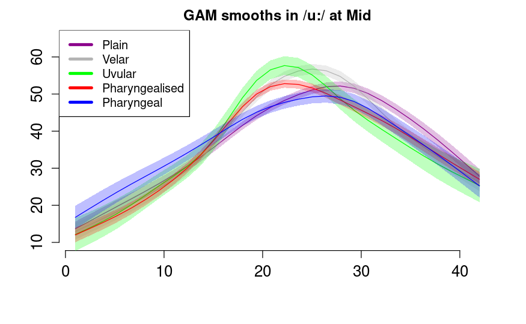

```r
legend("topleft", legend=c("Plain", "Velar", "Uvular","Pharyngealised","Pharyngeal"),
       col=c("darkmagenta","gray70","green","red","blue"), lwd=4)
```

#### 3.6.3.3 Offset

```r
plot_smooth(phar.gam.AR, view = "Fan",cond = list(context.ord="plain",vowel.ord="uu",time=3),col="darkmagenta",ylim = c(10,65),ylab="",xlab="",
            main="GAM smooths in /u:/ at Offset",hide.label=T,cex.axis=1.3,rm.ranef=T)
```

```
Summary:
    * context.ord : factor; set to the value(s): plain.
    * vowel.ord : factor; set to the value(s): uu.
    * Fan : numeric predictor; with 30 values ranging from 1.000000 to 42.000000.
    * time : numeric predictor; set to the value(s): 3.
    * word : factor; set to the value(s): 2aa3aa. (Might be canceled as random effect, check below.)
    * NOTE : The following random effects columns are canceled: s(Fan,word),s(time,word)
```

```r
plot_smooth(phar.gam.AR, view = "Fan",cond = list(context.ord="velar",vowel.ord="uu",time=3),col="gray70",add=TRUE,ylim = c(10,65),hide.label=T,cex.axis=1.3,rm.ranef=T)
```

```
Summary:
    * context.ord : factor; set to the value(s): velar.
    * vowel.ord : factor; set to the value(s): uu.
    * Fan : numeric predictor; with 30 values ranging from 1.000000 to 42.000000.
    * time : numeric predictor; set to the value(s): 3.
    * word : factor; set to the value(s): 2aa3aa. (Might be canceled as random effect, check below.)
    * NOTE : The following random effects columns are canceled: s(Fan,word),s(time,word)
```

```r
plot_smooth(phar.gam.AR, view = "Fan",cond = list(context.ord="uvular",vowel.ord="uu",time=3),col="green",add=TRUE,ylim = c(10,65),hide.label=T,cex.axis=1.3,rm.ranef=T)
```

```
Summary:
    * context.ord : factor; set to the value(s): uvular.
    * vowel.ord : factor; set to the value(s): uu.
    * Fan : numeric predictor; with 30 values ranging from 1.000000 to 42.000000.
    * time : numeric predictor; set to the value(s): 3.
    * word : factor; set to the value(s): 2aa3aa. (Might be canceled as random effect, check below.)
    * NOTE : The following random effects columns are canceled: s(Fan,word),s(time,word)
```

```r
plot_smooth(phar.gam.AR, view = "Fan",cond = list(context.ord="pharyngealised",vowel.ord="uu",time=3),col="red",add=TRUE,ylim = c(10,65),hide.label=T,cex.axis=1.3,rm.ranef=T)
```

```
Summary:
    * context.ord : factor; set to the value(s): pharyngealised.
    * vowel.ord : factor; set to the value(s): uu.
    * Fan : numeric predictor; with 30 values ranging from 1.000000 to 42.000000.
    * time : numeric predictor; set to the value(s): 3.
    * word : factor; set to the value(s): 2aa3aa. (Might be canceled as random effect, check below.)
    * NOTE : The following random effects columns are canceled: s(Fan,word),s(time,word)
```

```r
plot_smooth(phar.gam.AR, view = "Fan",cond = list(context.ord="pharyngeal",vowel.ord="uu",time=3),col="blue",add=TRUE,ylim = c(10,65),hide.label=T,cex.axis=1.3,rm.ranef=T)
```

```
Summary:
    * context.ord : factor; set to the value(s): pharyngeal.
    * vowel.ord : factor; set to the value(s): uu.
    * Fan : numeric predictor; with 30 values ranging from 1.000000 to 42.000000.
    * time : numeric predictor; set to the value(s): 3.
    * word : factor; set to the value(s): 2aa3aa. (Might be canceled as random effect, check below.)
    * NOTE : The following random effects columns are canceled: s(Fan,word),s(time,word)
```

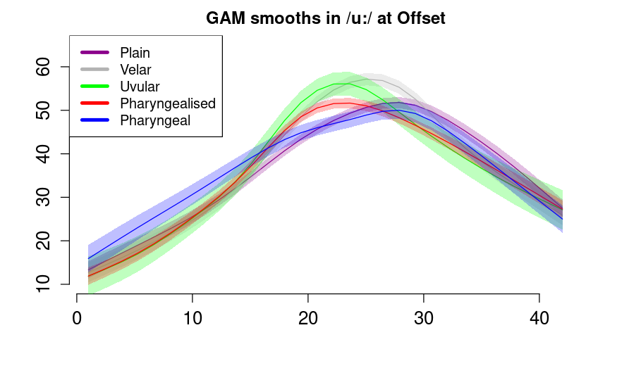

```r
legend("topleft", legend=c("Plain", "Velar", "Uvular","Pharyngealised","Pharyngeal"),
       col=c("darkmagenta","gray70","green","red","blue"), lwd=4)
```

```r
NA
NA
```

## 3.7 Visualising Difference smooths from second Autoregressive GAM

We use the function itsadug::plot_diff to plot the differences between the following pairs: “pharyngealised” vs “plain”; “uvular” vs “pharyngealised” and “pharyngealised” vs “pharyngeal”, in each of the vowel contexts /i: a: u:/ at the onset, midpoint and offset.

The results show that:

1. Pharyngealised vs Plain: pharyngealised is different in tongue shape. There is an increase in y coordinates (Fan 15-22) indicating “retraction”, decrease (Fan 25-35) indicating “depression” of the tongue and potential difference in larynx height (Fan 5-10)
2. Uvular vs Pharyngealised: differences depend of vowels (Fan 15-34): uvular is fronter in /i:/ (Fan 22-34); “raised” in /a:/ (Fan 22-28) and /u:/ (Fan 15-25)
3. Pharyngealised vs Pharyngeal: Pharyngealised is “retracted”/backed to mid-position (Fan 15-25), with “depression” of the tongue (Fan 22-35) and potential lowered larynx (Fan 5-10).

### 3.7.1 Pharyngealised vs Plain

#### 3.7.1.1 Onset

```r
par(oma=c(1, 0, 0, 3.5),mgp=c(2, 1, 0))
plot_diff(phar.gam.AR, view="Fan",comp=list(context.ord=c("pharyngealised","plain")),
          xlab="",cond=list(time=1,vowel.ord="ii"),main = "difference pharyngealised vs plain Onset",
          col='green',cex.main=1.1,mark.diff = TRUE,col.diff = "green",
          ylim=c(-15,15),hide.label=T,rm.ranef=T)
```

```
Summary:
    * vowel.ord : factor; set to the value(s): ii.
    * Fan : numeric predictor; with 100 values ranging from 1.000000 to 42.000000.
    * time : numeric predictor; set to the value(s): 1.
    * word : factor; set to the value(s): 2aa3aa. (Might be canceled as random effect, check below.)
    * NOTE : The following random effects columns are canceled: s(Fan,word),s(time,word)


Fan window(s) of significant difference(s):
    10.939394 - 23.363636
    26.262626 - 38.686869
```

```r
plot_diff(phar.gam.AR, view="Fan",comp=list(context.ord=c("pharyngealised","plain")),
          xlab="",cond=list(time=1,vowel.ord="aa"),add=TRUE,
          col='red',mark.diff =  TRUE,col.diff = "red",
          ylim=c(-15,15),hide.label=T,rm.ranef=T)
```

```
Summary:
    * vowel.ord : factor; set to the value(s): aa.
    * Fan : numeric predictor; with 100 values ranging from 1.000000 to 42.000000.
    * time : numeric predictor; set to the value(s): 1.
    * word : factor; set to the value(s): 2aa3aa. (Might be canceled as random effect, check below.)
    * NOTE : The following random effects columns are canceled: s(Fan,word),s(time,word)


Fan window(s) of significant difference(s):
    11.353535 - 22.535354
    25.434343 - 35.373737
```

```r
plot_diff(phar.gam.AR, view="Fan",comp=list(context.ord=c("pharyngealised","plain")),
          xlab="",cond=list(time=1,vowel.ord="uu"),add=TRUE,
          col='blue',mark.diff =  TRUE,col.diff = "blue",
          ylim=c(-15,15),hide.label=T,rm.ranef=T)
```

```
Summary:
    * vowel.ord : factor; set to the value(s): uu.
    * Fan : numeric predictor; with 100 values ranging from 1.000000 to 42.000000.
    * time : numeric predictor; set to the value(s): 1.
    * word : factor; set to the value(s): 2aa3aa. (Might be canceled as random effect, check below.)
    * NOTE : The following random effects columns are canceled: s(Fan,word),s(time,word)


Fan window(s) of significant difference(s):
    4.313131 - 9.282828
    15.080808 - 23.363636
    25.848485 - 37.858586
```

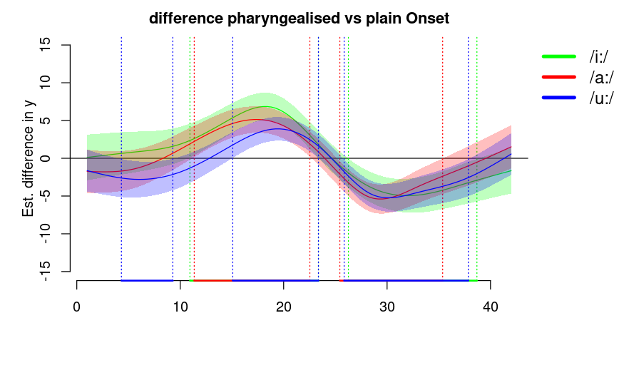

```r
legend(par('usr')[2], par('usr')[4], bty='n', xpd=NA,lty=1,
       legend=c("/i:/", "/a:/", "/u:/"),col=c("green","red","blue"), lwd=4, cex=1.2)
```

#### 3.7.1.2 Midpoint

```r
par(oma=c(1, 0, 0, 3.5),mgp=c(2, 1, 0))
plot_diff(phar.gam.AR, view="Fan",comp=list(context.ord=c("pharyngealised","plain")),
          xlab="",cond=list(time=2,vowel.ord="ii"),main = "difference pharyngealised vs plain Midpoint",
          col='green',cex.main=1.1,mark.diff = TRUE,col.diff = "green",
          ylim=c(-15,15),hide.label=T,rm.ranef=T)
```

```
Summary:
    * vowel.ord : factor; set to the value(s): ii.
    * Fan : numeric predictor; with 100 values ranging from 1.000000 to 42.000000.
    * time : numeric predictor; set to the value(s): 2.
    * word : factor; set to the value(s): 2aa3aa. (Might be canceled as random effect, check below.)
    * NOTE : The following random effects columns are canceled: s(Fan,word),s(time,word)


Fan window(s) of significant difference(s):
    4.727273 - 24.191919
    25.848485 - 41.171717
```

```r
plot_diff(phar.gam.AR, view="Fan",comp=list(context.ord=c("pharyngealised","plain")),
          xlab="",cond=list(time=2,vowel.ord="aa"),add=TRUE,
          col='red',mark.diff =  TRUE,col.diff = "red",
          ylim=c(-15,15),hide.label=T,rm.ranef=T)
```

```
Summary:
    * vowel.ord : factor; set to the value(s): aa.
    * Fan : numeric predictor; with 100 values ranging from 1.000000 to 42.000000.
    * time : numeric predictor; set to the value(s): 2.
    * word : factor; set to the value(s): 2aa3aa. (Might be canceled as random effect, check below.)
    * NOTE : The following random effects columns are canceled: s(Fan,word),s(time,word)


Fan window(s) of significant difference(s):
    13.838384 - 23.363636
    25.848485 - 36.616162
```

```r
plot_diff(phar.gam.AR, view="Fan",comp=list(context.ord=c("pharyngealised","plain")),
          xlab="",cond=list(time=2,vowel.ord="uu"),add=TRUE,
          col='blue',mark.diff =  TRUE,col.diff = "blue",
          ylim=c(-15,15),hide.label=T,rm.ranef=T)
```

```
Summary:
    * vowel.ord : factor; set to the value(s): uu.
    * Fan : numeric predictor; with 100 values ranging from 1.000000 to 42.000000.
    * time : numeric predictor; set to the value(s): 2.
    * word : factor; set to the value(s): 2aa3aa. (Might be canceled as random effect, check below.)
    * NOTE : The following random effects columns are canceled: s(Fan,word),s(time,word)


Fan window(s) of significant difference(s):
    5.141414 - 8.454545
    15.080808 - 24.191919
    26.676768 - 39.515152
```

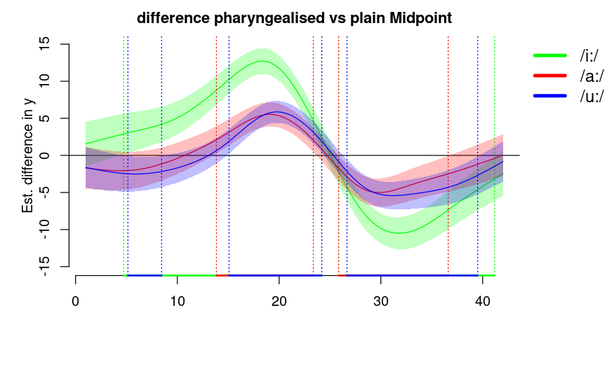

```r
legend(par('usr')[2], par('usr')[4], bty='n', xpd=NA,lty=1,
       legend=c("/i:/", "/a:/", "/u:/"),col=c("green","red","blue"), lwd=4, cex=1.2)
```

#### 3.7.1.3 Offset

```r
par(oma=c(1, 0, 0, 3.5),mgp=c(2, 1, 0))
plot_diff(phar.gam.AR, view="Fan",comp=list(context.ord=c("pharyngealised","plain")),
          xlab="",cond=list(time=3,vowel.ord="ii"),main = "difference pharyngealised vs plain Offset",
          col='green',cex.main=1.1,mark.diff = TRUE,col.diff = "green",
          ylim=c(-15,15),hide.label=T,rm.ranef=T)
```

```
Summary:
    * vowel.ord : factor; set to the value(s): ii.
    * Fan : numeric predictor; with 100 values ranging from 1.000000 to 42.000000.
    * time : numeric predictor; set to the value(s): 3.
    * word : factor; set to the value(s): 2aa3aa. (Might be canceled as random effect, check below.)
    * NOTE : The following random effects columns are canceled: s(Fan,word),s(time,word)


Fan window(s) of significant difference(s):
    5.969697 - 25.020202
    26.676768 - 41.171717
```

```r
plot_diff(phar.gam.AR, view="Fan",comp=list(context.ord=c("pharyngealised","plain")),
          xlab="",cond=list(time=3,vowel.ord="aa"),add=TRUE,
          col='red',mark.diff =  TRUE,col.diff = "red",
          ylim=c(-15,15),hide.label=T,rm.ranef=T)
```

```
Summary:
    * vowel.ord : factor; set to the value(s): aa.
    * Fan : numeric predictor; with 100 values ranging from 1.000000 to 42.000000.
    * time : numeric predictor; set to the value(s): 3.
    * word : factor; set to the value(s): 2aa3aa. (Might be canceled as random effect, check below.)
    * NOTE : The following random effects columns are canceled: s(Fan,word),s(time,word)


Fan window(s) of significant difference(s):
    1.828283 - 6.797980
    14.666667 - 23.363636
    26.262626 - 34.959596
```

```r
plot_diff(phar.gam.AR, view="Fan",comp=list(context.ord=c("pharyngealised","plain")),
          xlab="",cond=list(time=3,vowel.ord="uu"),add=TRUE,
          col='blue',mark.diff =  TRUE,col.diff = "blue",
          ylim=c(-15,15),hide.label=T,rm.ranef=T)
```

```
Summary:
    * vowel.ord : factor; set to the value(s): uu.
    * Fan : numeric predictor; with 100 values ranging from 1.000000 to 42.000000.
    * time : numeric predictor; set to the value(s): 3.
    * word : factor; set to the value(s): 2aa3aa. (Might be canceled as random effect, check below.)
    * NOTE : The following random effects columns are canceled: s(Fan,word),s(time,word)


Fan window(s) of significant difference(s):
    14.252525 - 23.777778
    26.676768 - 38.686869
```

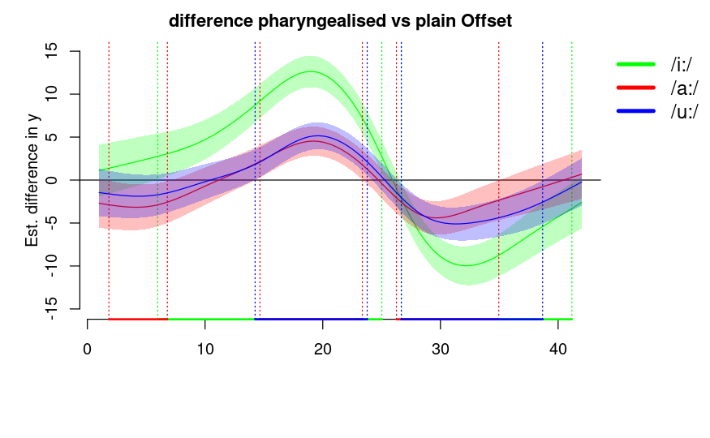

```r
legend(par('usr')[2], par('usr')[4], bty='n', xpd=NA,lty=1,
       legend=c("/i:/", "/a:/", "/u:/"),col=c("green","red","blue"), lwd=4, cex=1.2)
```

### 3.7.2 Uvular vs Pharyngealised

#### 3.7.2.1 Onset

```r
par(oma=c(1, 0, 0, 3.5),mgp=c(2, 1, 0))
plot_diff(phar.gam.AR, view="Fan",comp=list(context.ord=c("uvular","pharyngealised")),
          xlab="",cond=list(time=1,vowel.ord="ii"),main = "difference uvular vs pharyngealised Onset",
          col='green',cex.main=1.1,mark.diff = TRUE,col.diff = "green",
          ylim=c(-15,15),hide.label=T,rm.ranef=T)
```

```
Summary:
    * vowel.ord : factor; set to the value(s): ii.
    * Fan : numeric predictor; with 100 values ranging from 1.000000 to 42.000000.
    * time : numeric predictor; set to the value(s): 1.
    * word : factor; set to the value(s): 2aa3aa. (Might be canceled as random effect, check below.)
    * NOTE : The following random effects columns are canceled: s(Fan,word),s(time,word)


Difference is not significant.
```

```r
plot_diff(phar.gam.AR, view="Fan",comp=list(context.ord=c("uvular","pharyngealised")),
          xlab="",cond=list(time=1,vowel.ord="aa"),add=TRUE,
          col='red',mark.diff =  TRUE,col.diff = "red",
          ylim=c(-15,15),hide.label=T,rm.ranef=T)
```

```
Summary:
    * vowel.ord : factor; set to the value(s): aa.
    * Fan : numeric predictor; with 100 values ranging from 1.000000 to 42.000000.
    * time : numeric predictor; set to the value(s): 1.
    * word : factor; set to the value(s): 2aa3aa. (Might be canceled as random effect, check below.)
    * NOTE : The following random effects columns are canceled: s(Fan,word),s(time,word)


Fan window(s) of significant difference(s):
    24.606061 - 30.404040
```

```r
plot_diff(phar.gam.AR, view="Fan",comp=list(context.ord=c("uvular","pharyngealised")),
          xlab="",cond=list(time=1,vowel.ord="uu"),add=TRUE,
          col='blue',mark.diff =  TRUE,col.diff = "blue",
          ylim=c(-15,15),hide.label=T,rm.ranef=T)
```

```
Summary:
    * vowel.ord : factor; set to the value(s): uu.
    * Fan : numeric predictor; with 100 values ranging from 1.000000 to 42.000000.
    * time : numeric predictor; set to the value(s): 1.
    * word : factor; set to the value(s): 2aa3aa. (Might be canceled as random effect, check below.)
    * NOTE : The following random effects columns are canceled: s(Fan,word),s(time,word)


Difference is not significant.
```

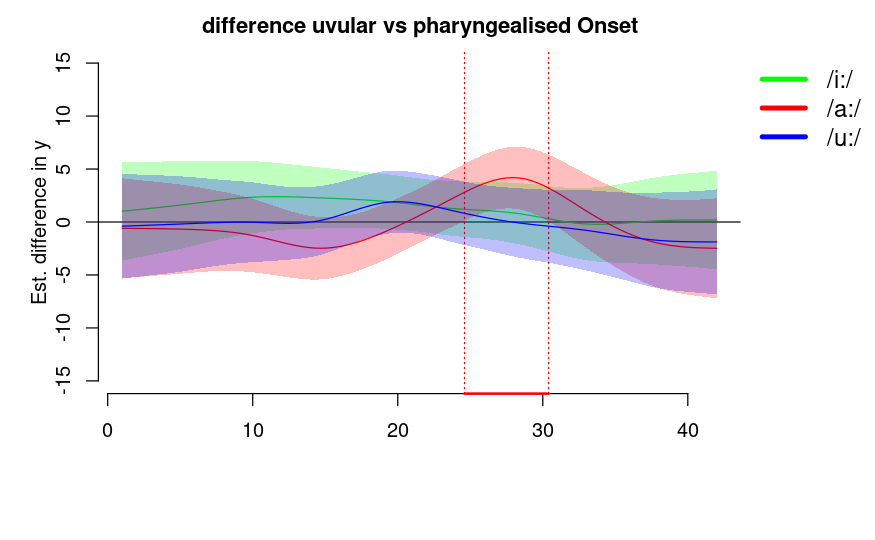

```r
legend(par('usr')[2], par('usr')[4], bty='n', xpd=NA,lty=1,
       legend=c("/i:/", "/a:/", "/u:/"),col=c("green","red","blue"), lwd=4, cex=1.2)
```

#### 3.7.2.2 Midpoint

```r
par(oma=c(1, 0, 0, 3.5),mgp=c(2, 1, 0))
plot_diff(phar.gam.AR, view="Fan",comp=list(context.ord=c("uvular","pharyngealised")),
          xlab="",cond=list(time=2,vowel.ord="ii"),main = "difference uvular vs pharyngealised Midpoint",
          col='green',cex.main=1.1,mark.diff = TRUE,col.diff = "green",
          ylim=c(-15,15),hide.label=T,rm.ranef=T)
```

```
Summary:
    * vowel.ord : factor; set to the value(s): ii.
    * Fan : numeric predictor; with 100 values ranging from 1.000000 to 42.000000.
    * time : numeric predictor; set to the value(s): 2.
    * word : factor; set to the value(s): 2aa3aa. (Might be canceled as random effect, check below.)
    * NOTE : The following random effects columns are canceled: s(Fan,word),s(time,word)


Fan window(s) of significant difference(s):
    20.878788 - 32.474747
```

```r
plot_diff(phar.gam.AR, view="Fan",comp=list(context.ord=c("uvular","pharyngealised")),
          xlab="",cond=list(time=2,vowel.ord="aa"),add=TRUE,
          col='red',mark.diff =  TRUE,col.diff = "red",
          ylim=c(-15,15),hide.label=T,rm.ranef=T)
```

```
Summary:
    * vowel.ord : factor; set to the value(s): aa.
    * Fan : numeric predictor; with 100 values ranging from 1.000000 to 42.000000.
    * time : numeric predictor; set to the value(s): 2.
    * word : factor; set to the value(s): 2aa3aa. (Might be canceled as random effect, check below.)
    * NOTE : The following random effects columns are canceled: s(Fan,word),s(time,word)


Fan window(s) of significant difference(s):
    19.636364 - 28.747475
    35.787879 - 37.858586
```

```r
plot_diff(phar.gam.AR, view="Fan",comp=list(context.ord=c("uvular","pharyngealised")),
          xlab="",cond=list(time=2,vowel.ord="uu"),add=TRUE,
          col='blue',mark.diff =  TRUE,col.diff = "blue",
          ylim=c(-15,15),hide.label=T,rm.ranef=T)
```

```
Summary:
    * vowel.ord : factor; set to the value(s): uu.
    * Fan : numeric predictor; with 100 values ranging from 1.000000 to 42.000000.
    * time : numeric predictor; set to the value(s): 2.
    * word : factor; set to the value(s): 2aa3aa. (Might be canceled as random effect, check below.)
    * NOTE : The following random effects columns are canceled: s(Fan,word),s(time,word)


Fan window(s) of significant difference(s):
    18.808081 - 25.434343
```

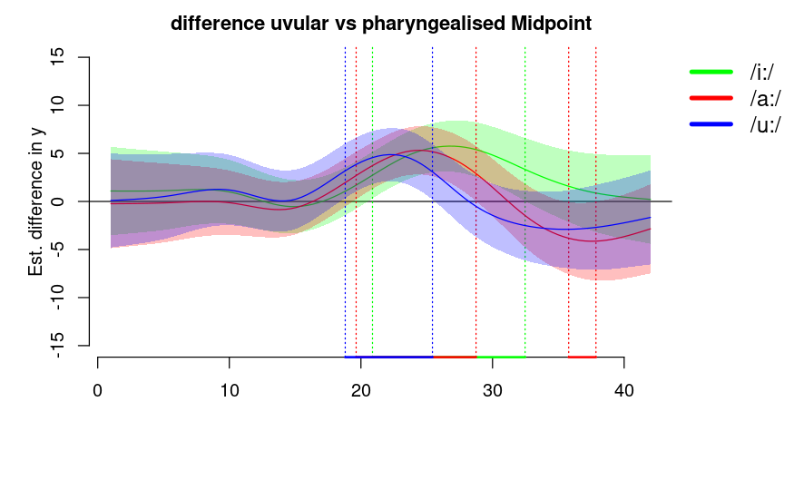

```r
legend(par('usr')[2], par('usr')[4], bty='n', xpd=NA,lty=1,
       legend=c("/i:/", "/a:/", "/u:/"),col=c("green","red","blue"), lwd=4, cex=1.2)
```